# Zwischenbericht MSB

- Show All Code
- Hide All Code
- View Source

Author

Affiliation

Jürgen Schneider

DIPF

Published

May 31, 2024

# 1 Preparation

**Import data**

```r
# k1k2 <- rio::import(here("data/07_LSI_MZP123456_Lehramtneu_UTF-8.csv"))
k1k2 <- rio::import(here("data/07_LSI_MZP123456_Lehramtneu_Unicode.sav"))
# k1k2_laa_mzp1 <- rio::import(here("data/BilWiss_MZP1.sav"))

k3_laa <- rio::import(here("data/LAA_K3_2024-04-11.sav")) # K3 der LAA MZP 1 und MZP 2

k4_laa_mzp1 <- rio::import(here("data/LAA_K4_MZP1_2024-04-15.sav")) # K4 der LAA aus MZP 1
k4_alk_mzp1 <- rio::import(here("data/ALK_K4_MZP1_2024-05-22.sav")) # K4 der ALK aus MZP 1
k4_sab_mzp1 <- rio::import(here("data/SAB_K4_MZP1_2024-03-11.sav")) # K4 der SAB aus MZP 1
```

Alle genutzten Daten entstammen den MZP 1 der jeweiligen Kohorten.

**Data wrangling**

Auswahl der Skalen und wrangling der Daten.

### 1.0.1 K1 & K2 LAA

```r
k1k2 <- k1k2 |>
  dplyr::mutate(kohorte = as.factor(kohorte)) |>
  dplyr::select(kohorte,
                UL_1,
                LE_1,
                DE_1,
                BT_1,
                SP_1,
                LB_1,
                entu_1,
                entf_1,
                efft_1,
                ee_1,
                engak_1) |>
  dplyr::rename_with(~ gsub("_1", "", .x, fixed = TRUE)) |> # Löschen von _01 in den Variablennamen
  dplyr::rename(c(BilWiss_ul = UL,         # umbenennen der Variblen für das Matching
                  BilWiss_le = LE,
                  BilWiss_de = DE,
                  BilWiss_bt = BT,
                  BilWiss_sb = SP,
                  BilWiss_lb = LB,
                  bel = ee,
                  aen = engak)) |>
  dplyr::mutate(#kohorte = as.factor("1+2"),    # Variable zur Unterscheidung der Kohorten
                gruppe = as.factor("laa"))   # Variable zur Unterscheidung der Gruppen



# k1k2_laa_mzp1 <- k1k2_laa_mzp1 |>
#   dplyr::mutate(kohorte = as.factor(kohorte)) |>
#   dplyr::select(kohorte,
#                 UL_1,
#                 LE_1,
#                 DE_1,
#                 BT_1,
#                 SP_1,
#                 LB_1,
#                 entu_1,
#                 entf_1,
#                 efft_1,
#                 ee_1,
#                 engak_1) |>
#   dplyr::rename_with(~ gsub("_1", "", .x, fixed = TRUE)) |> # Löschen von _01 in den Variablennamen
#   dplyr::rename(c(BilWiss_ul = UL,         # umbenennen der Variblen für das Matching
#                   BilWiss_le = LE,
#                   BilWiss_de = DE,
#                   BilWiss_bt = BT,
#                   BilWiss_sb = SP,
#                   BilWiss_lb = LB,
#                   bel = ee,
#                   aen = engak)) |>
#   dplyr::mutate(#kohorte = as.factor("1+2"),    # Variable zur Unterscheidung der Kohorten
#                 gruppe = as.factor("laa"))   # Variable zur Unterscheidung der Gruppen
```

### 1.0.2 K3 LAA

```r
k3_laa <- k3_laa |>
  dplyr::select(Score_Kurz_01,               # Auswahl der Variablen
                Score_BT_KT_01,
                Score_DE_KT_01,
                Score_LB_KT_01,
                Score_LE_KT_01,
                Score_SB_KT_01,
                Score_UN_KT_01,
                tp_01,
                entu_01,
                entf_01,
                efft_01,
                rfbe_01,
                meko_1_01 : meko_7_01,
                mekos_01,
                bel_01,
                aen_01,
                zfr_01,
                uebr_01,
                uebk_01) |>
  dplyr::rename_with(~ gsub("_01", "", .x, fixed = TRUE)) |> # Löschen von _01 in den Variablennamen
  dplyr::rename(c(BilWiss_kurz = Score_Kurz,         # umbenennen der Variblen für das Matching
                  BilWiss_ul = Score_UN_KT,
                  BilWiss_le = Score_LE_KT,
                  BilWiss_de = Score_DE_KT,
                  BilWiss_bt = Score_BT_KT,
                  BilWiss_sb = Score_SB_KT,
                  BilWiss_lb = Score_LB_KT)) |>
  dplyr::mutate(kohorte = as.factor("3"),    # Variable zur Unterscheidung der Kohorten
                gruppe = as.factor("laa"))   # Variable zur Unterscheidung der Gruppen
```

### 1.0.3 K4 LAA

```r
k4_laa_mzp1 <- k4_laa_mzp1 |>
  dplyr::select(Score_Kurz_01K4,             # Auswahl der Variablen
                Score_BT_KT_01K4,
                Score_DE_KT_01K4,
                Score_LB_KT_01K4,
                Score_LE_KT_01K4,
                Score_SB_KT_01K4,
                Score_UN_KT_01K4,
                tp_01K4,
                entu_01K4,
                entf_01K4,
                efft_01K4,
                rfbe_01K4,
                meko_1_01K4 : meko_7_01K4,
                mekos_01K4,
                tpkcon_score_01K4,
                tpksit_score_01K4,
                tpkpot_score_01K4,
                tpksup_score_01K4,
                tpksit_score_av_01K4,
                tpksit_score_tb_01K4,
                tpksit_score_aa_01K4,
                bel_01K4,
                aen_01K4,
                zfr_01K4,
                palsma_01K4,
                uebr_01K4,
                uebk_01K4,
                ub_8_01K4,
                ub_3_01K4,
                ub_7_01K4) |>
  dplyr::rename_with(~ gsub("_01K4", "", .x, fixed = TRUE)) |> # Löschen von _01K4 in den Variablennamen
  dplyr::rename(c(BilWiss_kurz = Score_Kurz,         # umbenennen der Variblen für das Matching
                  BilWiss_ul = Score_UN_KT,
                  BilWiss_le = Score_LE_KT,
                  BilWiss_de = Score_DE_KT,
                  BilWiss_bt = Score_BT_KT,
                  BilWiss_sb = Score_SB_KT,
                  BilWiss_lb = Score_LB_KT)) |>
  dplyr::mutate(kohorte = as.factor("4"),    # Variable zur Unterscheidung der Kohorten
                gruppe = as.factor("laa"))   # Variable zur Unterscheidung der Gruppen
```

### 1.0.4 K4 ALK

```r
k4_alk_mzp1 <- k4_alk_mzp1 |>
  dplyr::select(AUNLT_01K4,             # Auswahl der Variablen
                AUNL_01K4,
                INNO_01K4,
                EE_01K4,
                ENGA_01K4,
                ZFR_01K4,
                QUIT_01K4,
                # LZ_01K4,   # In der Skalendoku aber nicht im Datensatz
                eignp_01K4,
                eign_01_01K4,
                KOOP_01K4,
                SOZ_01K4,
                ubvorA_1_01K4,
                ubvorB_1_01K4,
                ubvorC_1_01K4,
                ubnach_1_01K4,
                ubnach_2_01K4,
                ubnach_3_01K4,
                ubnach_4_01K4,
                tpkcon_score_01K4,
                tpksit_score_01K4,
                tpkpot_score_01K4,
                tpksup_score_01K4,
                tpksit_score_av_01K4,
                tpksit_score_tb_01K4,
                tpksit_score_aa_01K4) |>
  dplyr::rename_with(~ gsub("_01K4", "", .x, fixed = TRUE)) |> # Löschen von _01K4 in den Variablennamen
  dplyr::rename(c(KOZA = KOOP,                       # umbenennen der Variblen für das Matching
                  bel = EE,
                  aen = ENGA,
                  zfr = ZFR,
                  uebr = AUNLT,
                  uebk = AUNL)) |>
  dplyr::mutate(kohorte = as.factor("4"),    # Variable zur Unterscheidung der Kohorten
                gruppe = as.factor("alk"))   # Variable zur Unterscheidung der Gruppen
```

### 1.0.5 K4 SAB

```r
k4_sab_mzp1 <- k4_sab_mzp1 |>
  dplyr::select(AUNLT_01K4,             # Auswahl der Variablen
                AUNL_01K4,
                TPZU_01K4,
                INNO_01K4,
                EXKO_01K4,
                EE_01K4,
                ENGA_01K4,
                ZFR_01K4,
                QUIT_01K4,
                SExMPART_01K4,
                LZ_01K4,
                eignp_01K4,
                eign_01_01K4,
                KOZA_01K4,
                SOZ_01K4,
                MEKOS_01K4,
                tpkcon_score_01K4,
                tpksit_score_01K4,
                tpkpot_score_01K4,
                tpksup_score_01K4,
                tpksit_score_av_01K4,
                tpksit_score_tb_01K4,
                tpksit_score_aa_01K4,
                Filterfrage_01K4) |>
  dplyr::rename_with(~ gsub("_01K4", "", .x, fixed = TRUE)) |> # Löschen von _01K4 in den Variablennamen
  dplyr::rename(c(bel = EE,                       # umbenennen der Variblen für das Matching
                  aen = ENGA,
                  zfr = ZFR,
                  uebr = AUNLT,
                  uebk = AUNL)) |>
  dplyr::mutate(kohorte = as.factor("4"),    # Variable zur Unterscheidung der Kohorten
                gruppe = as.factor("sab"))   # Variable zur Unterscheidung der Gruppen
```

**Matching**

```r
nrw <- dplyr::bind_rows(k1k2,
                        k3_laa,
                        k4_laa_mzp1,
                        k4_alk_mzp1,
                        k4_sab_mzp1)
```

# 2 Analyses

```r
# Funktion erstellen, die violin plots generiert
violin_plot <- function (data, variable, vergleich = "kohorte") {
  ggplot(data, aes_string(x = vergleich,
                  y = variable,
                  fill = vergleich,
                  color = vergleich)) +
    geom_violin(color = "grey",
                draw_quantiles = c(0.25, 0.75),
                trim  = T,
                linetype = "dashed",
                size = 1,
                alpha = .5) +
    stat_summary(fun.data = "mean_cl_boot",
                 size = 1) +
    scale_fill_viridis_d() +
    scale_color_viridis_d() +
    theme_light() +
    theme(panel.grid.major.x = element_blank(),
          panel.grid.major.y = element_blank(),
          panel.grid.minor.y = element_blank())
}
```

## 2.1 Start in den VB

“Wie starten die LAA in den Vorbereitungsdienst (Vergleiche zu K1, K2, K3)?”

### 2.1.1 BilWiss

pending

### 2.1.2 Überzeugungen: Theorie/Praxis Zusammenhang

**Abbildung**

```r
rm(p_var)
rm(p_vergleich)
rm(p_kohorten)
rm(p_gruppe)


############################################### #
### Welche VARIABLE soll ausgegeben werden?   ###
############################################### #
p_var <- "tp" # Variable in Anführungszeichen angeben

############################################### #
### Welcher VERGLEICH soll angestellt werden? ###
############################################### #
p_vergleich <- "kohorte" # Möglich ist: "kohorte" oder "gruppe"

############################################### #
### Welche KOHORTEN sollen ausgegeben werden? ###
############################################### #
p_kohorten <- c("3", "4") # Verfügbar: "1", "2", "3", "4"
                          # Einfach auskommentieren, wenn
                          # alle ausgegeben werden sollen

############################################### #
### Welche GRUPPEN sollen ausgegeben werden?  ###
############################################### #
p_gruppe <- c("laa") # Verfügbar: "laa" (Lehramtsanwärter*innen),
                     #            "sab" (Seminarausbilder*innen)
                     #            "alk" (Ausbildungslehrkräfte)
                     # Einfach auskommentieren, wenn
                     # alle ausgegeben werden sollen

nrw_p <- nrw
if (exists("p_kohorten")) {
  nrw_p <- nrw_p |>
    dplyr::filter(kohorte %in% p_kohorten)
}
if (exists("p_gruppe")) {
  nrw_p <- nrw_p |>
    dplyr::filter(gruppe %in% p_gruppe)
}
```

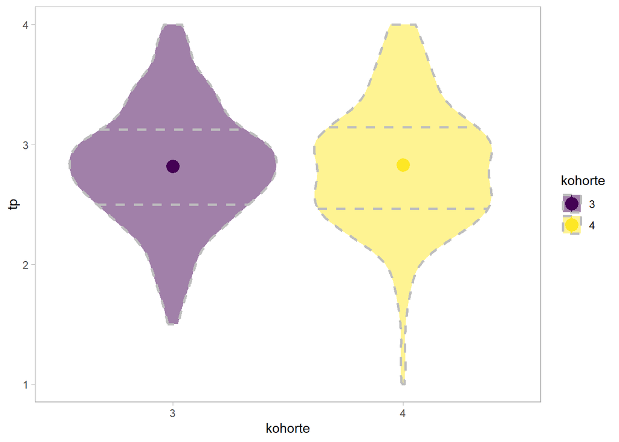

```r
violin_plot(nrw_p,
            eval(p_var),
            eval(p_vergleich))
```

**Deskriptive Ergebnisse**

In der Spalte “group1” wird angezeigt, um welche Gruppe (Nummer der Kohorte oder Gruppe) es sich in der jeweiligen Zeile handelt

```r
psych::describeBy(nrw_p[[p_var]],
                  group = droplevels(nrw_p[[p_vergleich]]),
                  mat=TRUE,
                  digits=3)
```

```
    item group1 vars   n  mean    sd median trimmed   mad min max range   skew
X11    1      3    1 648 2.817 0.494  2.833   2.821 0.494 1.5   4   2.5 -0.056
X12    2      4    1 619 2.831 0.511  2.833   2.823 0.494 1.0   4   3.0 -0.016
    kurtosis    se
X11   -0.014 0.019
X12    0.279 0.021
```

**Kohorten und Gruppen mit Daten**

Anzahl der Teilnehmenden je Gruppe und Kohorte:

```r
nrw %>%
  dplyr::filter(!is.na(get(p_var))) %>%
  {table(.$gruppe, .$kohorte)}
```

```
        1   2   3   4
  laa   0   0 648 619
  alk   0   0   0   0
  sab   0   0   0   0
```

**Abbildung**

```r
rm(p_var)
rm(p_vergleich)
rm(p_kohorten)
rm(p_gruppe)

############################################### #
### Welche VARIABLE soll ausgegeben werden?   ###
############################################### #
p_var <- "entu" # Variable in Anführungszeichen angeben

############################################### #
### Welcher VERGLEICH soll angestellt werden? ###
############################################### #
p_vergleich <- "kohorte" # Möglich ist: "kohorte" oder "gruppe"

############################################### #
### Welche KOHORTEN sollen ausgegeben werden? ###
############################################### #
# p_kohorten <- c("3", "4") # Verfügbar: "1", "2", "3", "4"
                          # Einfach auskommentieren, wenn
                          # alle ausgegeben werden sollen

############################################### #
### Welche GRUPPEN sollen ausgegeben werden?  ###
############################################### #
# p_gruppe <- c("laa") # Verfügbar: "laa" (Lehramtsanwärter*innen),
                     #            "sab" (Seminarausbilder*innen)
                     #            "alk" (Ausbildungslehrkräfte)
                     # Einfach auskommentieren, wenn
                     # alle ausgegeben werden sollen

nrw_p <- nrw
if (exists("p_kohorten")) {
  nrw_p <- nrw_p |>
    dplyr::filter(kohorte %in% p_kohorten)
}
if (exists("p_gruppe")) {
  nrw_p <- nrw_p |>
    dplyr::filter(gruppe %in% p_gruppe)
}
```

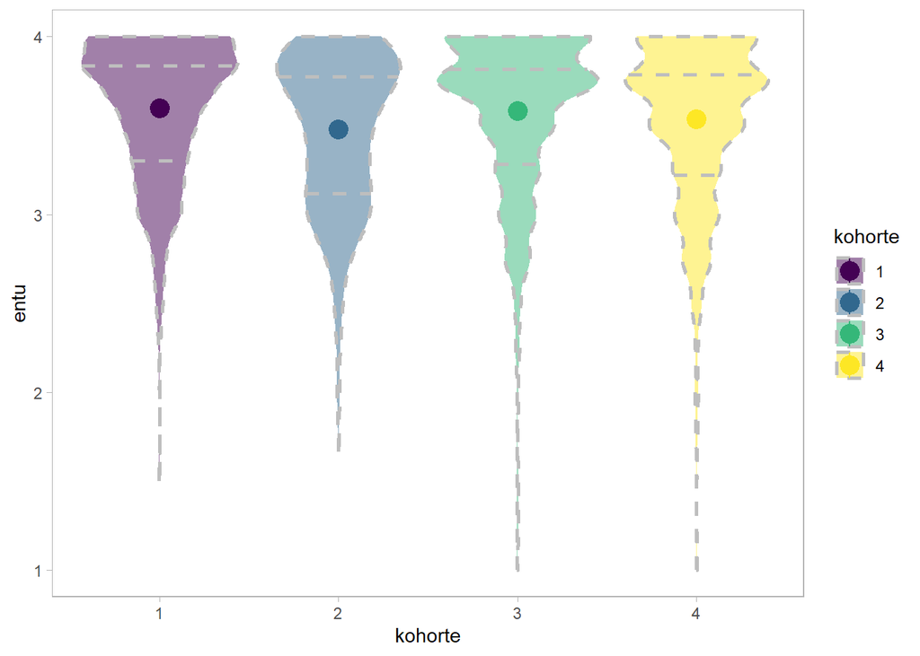

```r
violin_plot(nrw_p,
            eval(p_var),
            eval(p_vergleich))
```

**Deskriptive Ergebnisse**

In der Spalte “group1” wird angezeigt, um welche Gruppe (Nummer der Kohorte oder Gruppe) es sich in der jeweiligen Zeile handelt

```r
psych::describeBy(nrw_p[[p_var]],
                  group = droplevels(nrw_p[[p_vergleich]]),
                  mat=TRUE,
                  digits=3)
```

```
    item group1 vars    n  mean    sd median trimmed   mad   min max range
X11    1      1    1 1321 3.599 0.383  3.667   3.648 0.494 1.500   4 2.500
X12    2      2    1  482 3.477 0.435  3.633   3.518 0.445 1.667   4 2.333
X13    3      3    1  658 3.584 0.460  3.750   3.657 0.371 1.000   4 3.000
X14    4      4    1  600 3.535 0.450  3.750   3.597 0.371 1.000   4 3.000
      skew kurtosis    se
X11 -1.056    0.827 0.011
X12 -0.843    0.406 0.020
X13 -1.774    4.523 0.018
X14 -1.316    2.323 0.018
```

**Kohorten und Gruppen mit Daten**

Anzahl der Teilnehmenden je Gruppe und Kohorte:

```r
nrw %>%
  dplyr::filter(!is.na(get(p_var))) %>%
  {table(.$gruppe, .$kohorte)}
```

```
         1    2    3    4
  laa 1321  482  658  600
  alk    0    0    0    0
  sab    0    0    0    0
```

**Abbildung**

```r
rm(p_var)
rm(p_vergleich)
rm(p_kohorten)
rm(p_gruppe)

############################################### #
### Welche VARIABLE soll ausgegeben werden?   ###
############################################### #
p_var <- "entf" # Variable in Anführungszeichen angeben

############################################### #
### Welcher VERGLEICH soll angestellt werden? ###
############################################### #
p_vergleich <- "kohorte" # Möglich ist: "kohorte" oder "gruppe"

############################################### #
### Welche KOHORTEN sollen ausgegeben werden? ###
############################################### #
# p_kohorten <- c("3", "4") # Verfügbar: "1", "2", "3", "4"
                          # Einfach auskommentieren, wenn
                          # alle ausgegeben werden sollen

############################################### #
### Welche GRUPPEN sollen ausgegeben werden?  ###
############################################### #
# p_gruppe <- c("laa") # Verfügbar: "laa" (Lehramtsanwärter*innen),
                     #            "sab" (Seminarausbilder*innen)
                     #            "alk" (Ausbildungslehrkräfte)
                     # Einfach auskommentieren, wenn
                     # alle ausgegeben werden sollen

nrw_p <- nrw
if (exists("p_kohorten")) {
  nrw_p <- nrw_p |>
    dplyr::filter(kohorte %in% p_kohorten)
}
if (exists("p_gruppe")) {
  nrw_p <- nrw_p |>
    dplyr::filter(gruppe %in% p_gruppe)
}
```

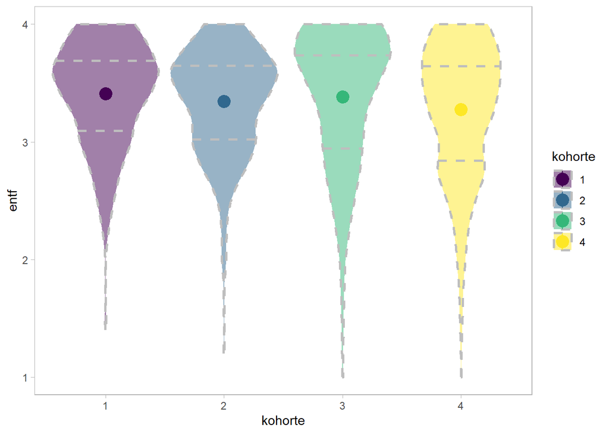

```r
violin_plot(nrw_p,
            eval(p_var),
            eval(p_vergleich))
```

**Deskriptive Ergebnisse**

In der Spalte “group1” wird angezeigt, um welche Gruppe (Nummer der Kohorte oder Gruppe) es sich in der jeweiligen Zeile handelt

```r
psych::describeBy(nrw_p[[p_var]],
                  group = droplevels(nrw_p[[p_vergleich]]),
                  mat=TRUE,
                  digits=3)
```

```
    item group1 vars   n  mean    sd median trimmed   mad min max range   skew
X11    1      1    1 527 3.410 0.439    3.4   3.446 0.593 1.4   4   2.6 -0.838
X12    2      2    1 484 3.346 0.444    3.4   3.377 0.593 1.2   4   2.8 -0.872
X13    3      3    1 658 3.383 0.569    3.5   3.453 0.371 1.0   4   3.0 -1.048
X14    4      4    1 600 3.274 0.566    3.5   3.324 0.371 1.0   4   3.0 -0.815
    kurtosis    se
X11    0.733 0.019
X12    1.165 0.020
X13    0.807 0.022
X14    0.401 0.023
```

**Kohorten und Gruppen mit Daten**

Anzahl der Teilnehmenden je Gruppe und Kohorte:

```r
nrw %>%
  dplyr::filter(!is.na(get(p_var))) %>%
  {table(.$gruppe, .$kohorte)}
```

```
        1   2   3   4
  laa 527 484 658 600
  alk   0   0   0   0
  sab   0   0   0   0
```

### 2.1.5 Selbstreg. Fähigkeiten: Effort-Trait

**Abbildung**

```r
rm(p_var)
rm(p_vergleich)
rm(p_kohorten)
rm(p_gruppe)

############################################### #
### Welche VARIABLE soll ausgegeben werden?   ###
############################################### #
p_var <- "efft" # Variable in Anführungszeichen angeben

############################################### #
### Welcher VERGLEICH soll angestellt werden? ###
############################################### #
p_vergleich <- "kohorte" # Möglich ist: "kohorte" oder "gruppe"

############################################### #
### Welche KOHORTEN sollen ausgegeben werden? ###
############################################### #
# p_kohorten <- c("3", "4") # Verfügbar: "1", "2", "3", "4"
                          # Einfach auskommentieren, wenn
                          # alle ausgegeben werden sollen

############################################### #
### Welche GRUPPEN sollen ausgegeben werden?  ###
############################################### #
# p_gruppe <- c("laa") # Verfügbar: "laa" (Lehramtsanwärter*innen),
                     #            "sab" (Seminarausbilder*innen)
                     #            "alk" (Ausbildungslehrkräfte)
                     # Einfach auskommentieren, wenn
                     # alle ausgegeben werden sollen

nrw_p <- nrw
if (exists("p_kohorten")) {
  nrw_p <- nrw_p |>
    dplyr::filter(kohorte %in% p_kohorten)
}
if (exists("p_gruppe")) {
  nrw_p <- nrw_p |>
    dplyr::filter(gruppe %in% p_gruppe)
}
```

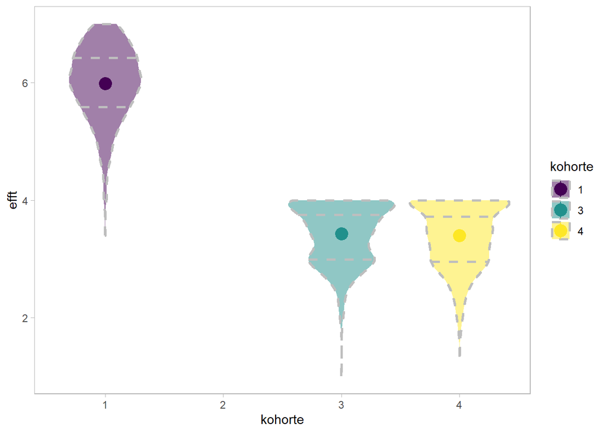

```r
violin_plot(nrw_p,
            eval(p_var),
            eval(p_vergleich))
```

**Deskriptive Ergebnisse**

In der Spalte “group1” wird angezeigt, um welche Gruppe (Nummer der Kohorte oder Gruppe) es sich in der jeweiligen Zeile handelt

```r
psych::describeBy(nrw_p[[p_var]],
                  group = droplevels(nrw_p[[p_vergleich]]),
                  mat=TRUE,
                  digits=3)
```

```
    item group1 vars   n  mean    sd median trimmed   mad   min  max range
X11    1      1    1 794 5.989 0.619    6.1   6.032 0.593 3.400    7 3.600
X12    2      2    1   0   NaN    NA     NA     NaN    NA   Inf -Inf  -Inf
X13    3      3    1 646 3.431 0.493    3.5   3.475 0.494 1.000    4 3.000
X14    4      4    1 594 3.397 0.531    3.5   3.451 0.741 1.333    4 2.667
      skew kurtosis    se
X11 -0.710    0.570 0.022
X12     NA       NA    NA
X13 -0.708    0.211 0.019
X14 -0.701   -0.048 0.022
```

**Kohorten und Gruppen mit Daten**

Anzahl der Teilnehmenden je Gruppe und Kohorte:

```r
nrw %>%
  dplyr::filter(!is.na(get(p_var))) %>%
  {table(.$gruppe, .$kohorte)}
```

```
        1   2   3   4
  laa 794   0 646 594
  alk   0   0   0   0
  sab   0   0   0   0
```

### 2.1.6 Selbstreg. Fähigkeiten: Reflexionsbereitschaft

**Abbildung**

```r
rm(p_var)
rm(p_vergleich)
rm(p_kohorten)
rm(p_gruppe)

############################################### #
### Welche VARIABLE soll ausgegeben werden?   ###
############################################### #
p_var <- "rfbe" # Variable in Anführungszeichen angeben

############################################### #
### Welcher VERGLEICH soll angestellt werden? ###
############################################### #
p_vergleich <- "kohorte" # Möglich ist: "kohorte" oder "gruppe"

############################################### #
### Welche KOHORTEN sollen ausgegeben werden? ###
############################################### #
# p_kohorten <- c("3", "4") # Verfügbar: "1", "2", "3", "4"
                          # Einfach auskommentieren, wenn
                          # alle ausgegeben werden sollen

############################################### #
### Welche GRUPPEN sollen ausgegeben werden?  ###
############################################### #
# p_gruppe <- c("laa") # Verfügbar: "laa" (Lehramtsanwärter*innen),
                     #            "sab" (Seminarausbilder*innen)
                     #            "alk" (Ausbildungslehrkräfte)
                     # Einfach auskommentieren, wenn
                     # alle ausgegeben werden sollen

nrw_p <- nrw
if (exists("p_kohorten")) {
  nrw_p <- nrw_p |>
    dplyr::filter(kohorte %in% p_kohorten)
}
if (exists("p_gruppe")) {
  nrw_p <- nrw_p |>
    dplyr::filter(gruppe %in% p_gruppe)
}
```

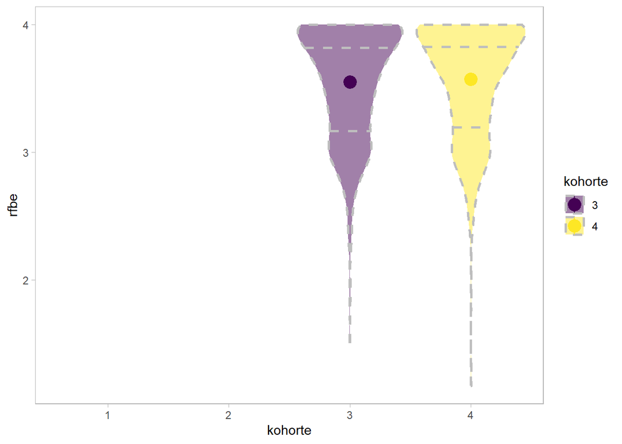

```r
violin_plot(nrw_p,
            eval(p_var),
            eval(p_vergleich))
```

**Deskriptive Ergebnisse**

In der Spalte “group1” wird angezeigt, um welche Gruppe (Nummer der Kohorte oder Gruppe) es sich in der jeweiligen Zeile handelt

```r
psych::describeBy(nrw_p[[p_var]],
                  group = droplevels(nrw_p[[p_vergleich]]),
                  mat=TRUE,
                  digits=3)
```

```
    item group1 vars   n  mean    sd median trimmed   mad   min  max range
X11    1      1    1   0   NaN    NA     NA     NaN    NA   Inf -Inf  -Inf
X12    2      2    1   0   NaN    NA     NA     NaN    NA   Inf -Inf  -Inf
X13    3      3    1 648 3.551 0.429  3.667   3.599 0.494 1.500    4 2.500
X14    4      4    1 597 3.573 0.422  3.667   3.623 0.494 1.167    4 2.833
      skew kurtosis    se
X11     NA       NA    NA
X12     NA       NA    NA
X13 -0.923    0.568 0.017
X14 -1.041    1.208 0.017
```

**Kohorten und Gruppen mit Daten**

Anzahl der Teilnehmenden je Gruppe und Kohorte:

```r
nrw %>%
  dplyr::filter(!is.na(get(p_var))) %>%
  {table(.$gruppe, .$kohorte)}
```

```
        1   2   3   4
  laa   0   0 648 597
  alk   0   0   0   0
  sab   0   0   0   0
```

### 2.1.7 Vorerfahrung Medienkompetenz

**Abbildung**

```r
rm(p_var)
rm(p_vergleich)
rm(p_kohorten)
rm(p_gruppe)

############################################### #
### Welche VARIABLE soll ausgegeben werden?   ###
############################################### #
# p_var <- "meko_1" # Variable in Anführungszeichen angeben

############################################### #
### Welcher VERGLEICH soll angestellt werden? ###
############################################### #
p_vergleich <- "kohorte" # Möglich ist: "kohorte" oder "gruppe"

############################################### #
### Welche KOHORTEN sollen ausgegeben werden? ###
############################################### #
p_kohorten <- c("3", "4") # Verfügbar: "1", "2", "3", "4"
                          # Einfach auskommentieren, wenn
                          # alle ausgegeben werden sollen

############################################### #
### Welche GRUPPEN sollen ausgegeben werden?  ###
############################################### #
# p_gruppe <- c("laa") # Verfügbar: "laa" (Lehramtsanwärter*innen),
                     #            "sab" (Seminarausbilder*innen)
                     #            "alk" (Ausbildungslehrkräfte)
                     # Einfach auskommentieren, wenn
                     # alle ausgegeben werden sollen

nrw_p <- nrw
if (exists("p_kohorten")) {
  nrw_p <- nrw_p |>
    dplyr::filter(kohorte %in% p_kohorten)
}
if (exists("p_gruppe")) {
  nrw_p <- nrw_p |>
    dplyr::filter(gruppe %in% p_gruppe)
}
```

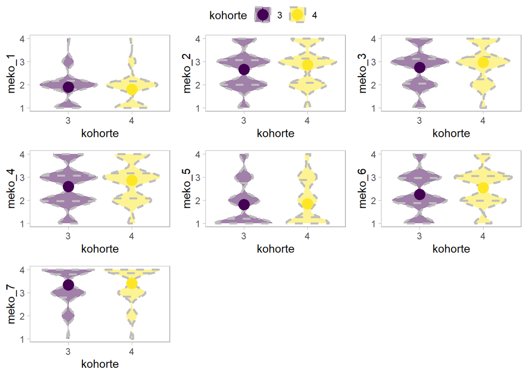

```r
p_var <- "meko_1" # Variable in Anführungszeichen angeben
p1 <- violin_plot(nrw_p,
            eval(p_var),
            eval(p_vergleich))

p_var <- "meko_2" # Variable in Anführungszeichen angeben
p2 <- violin_plot(nrw_p,
            eval(p_var),
            eval(p_vergleich))

p_var <- "meko_3" # Variable in Anführungszeichen angeben
p3 <- violin_plot(nrw_p,
            eval(p_var),
            eval(p_vergleich))

p_var <- "meko_4" # Variable in Anführungszeichen angeben
p4 <- violin_plot(nrw_p,
            eval(p_var),
            eval(p_vergleich))

p_var <- "meko_5" # Variable in Anführungszeichen angeben
p5 <- violin_plot(nrw_p,
            eval(p_var),
            eval(p_vergleich))

p_var <- "meko_6" # Variable in Anführungszeichen angeben
p6 <- violin_plot(nrw_p,
            eval(p_var),
            eval(p_vergleich))

p_var <- "meko_7" # Variable in Anführungszeichen angeben
p7 <- violin_plot(nrw_p,
            eval(p_var),
            eval(p_vergleich))

ggarrange(p1, p2, p3, p4, p5, p6, p7,
          ncol = 3,
          nrow = 3,
          align = "hv",
          common.legend = T)
```

**Deskriptive Ergebnisse**

In der Spalte “group1” wird angezeigt, um welche Gruppe (Nummer der Kohorte oder Gruppe) es sich in der jeweiligen Zeile handelt

```r
psych::describeBy(nrw_p[[p_var]],
                  group = droplevels(nrw_p[[p_vergleich]]),
                  mat=TRUE,
                  digits=3)
```

```
    item group1 vars   n  mean    sd median trimmed mad min max range   skew
X11    1      3    1 653 3.332 0.796      4   3.447   0   1   4     3 -0.974
X12    2      4    1 587 3.411 0.805      4   3.550   0   1   4     3 -1.226
    kurtosis    se
X11    0.183 0.031
X12    0.690 0.033
```

**Kohorten und Gruppen mit Daten**

Anzahl der Teilnehmenden je Gruppe und Kohorte:

```r
nrw %>%
  dplyr::filter(!is.na(get(p_var))) %>%
  {table(.$gruppe, .$kohorte)}
```

```
        1   2   3   4
  laa   0   0 653 587
  alk   0   0   0   0
  sab   0   0   0   0
```

### 2.1.8 Selbsteinschätzung Medienkompetenz

**Abbildung**

```r
rm(p_var)
rm(p_vergleich)
rm(p_kohorten)
rm(p_gruppe)

############################################### #
### Welche VARIABLE soll ausgegeben werden?   ###
############################################### #
p_var <- "mekos" # Variable in Anführungszeichen angeben

############################################### #
### Welcher VERGLEICH soll angestellt werden? ###
############################################### #
p_vergleich <- "kohorte" # Möglich ist: "kohorte" oder "gruppe"

############################################### #
### Welche KOHORTEN sollen ausgegeben werden? ###
############################################### #
# p_kohorten <- c("3", "4") # Verfügbar: "1", "2", "3", "4"
                          # Einfach auskommentieren, wenn
                          # alle ausgegeben werden sollen

############################################### #
### Welche GRUPPEN sollen ausgegeben werden?  ###
############################################### #
# p_gruppe <- c("laa") # Verfügbar: "laa" (Lehramtsanwärter*innen),
                     #            "sab" (Seminarausbilder*innen)
                     #            "alk" (Ausbildungslehrkräfte)
                     # Einfach auskommentieren, wenn
                     # alle ausgegeben werden sollen

nrw_p <- nrw
if (exists("p_kohorten")) {
  nrw_p <- nrw_p |>
    dplyr::filter(kohorte %in% p_kohorten)
}
if (exists("p_gruppe")) {
  nrw_p <- nrw_p |>
    dplyr::filter(gruppe %in% p_gruppe)
}
```

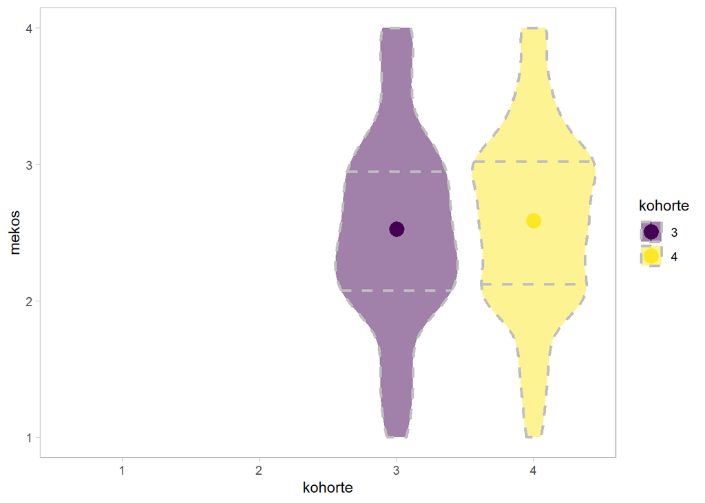

```r
violin_plot(nrw_p,
            eval(p_var),
            eval(p_vergleich))
```

**Deskriptive Ergebnisse**

In der Spalte “group1” wird angezeigt, um welche Gruppe (Nummer der Kohorte oder Gruppe) es sich in der jeweiligen Zeile handelt

```r
psych::describeBy(nrw_p[[p_var]],
                  group = droplevels(nrw_p[[p_vergleich]]),
                  mat=TRUE,
                  digits=3)
```

```
    item group1 vars   n  mean    sd median trimmed   mad min  max range   skew
X11    1      1    1   0   NaN    NA     NA     NaN    NA Inf -Inf  -Inf     NA
X12    2      2    1   0   NaN    NA     NA     NaN    NA Inf -Inf  -Inf     NA
X13    3      3    1 655 2.527 0.699    2.4   2.521 0.593   1    4     3  0.069
X14    4      4    1 584 2.588 0.666    2.6   2.595 0.593   1    4     3 -0.085
    kurtosis    se
X11       NA    NA
X12       NA    NA
X13   -0.224 0.027
X14   -0.234 0.028
```

**Kohorten und Gruppen mit Daten**

Anzahl der Teilnehmenden je Gruppe und Kohorte:

```r
nrw %>%
  dplyr::filter(!is.na(get(p_var))) %>%
  {table(.$gruppe, .$kohorte)}
```

```
        1   2   3   4
  laa   0   0 655 584
  alk   0   0   0   0
  sab   0   0   0   0
```

### 2.1.9 TPK: Konzeptuelles Wissen

**Abbildung**

```r
rm(p_var)
rm(p_vergleich)
rm(p_kohorten)
rm(p_gruppe)

############################################### #
### Welche VARIABLE soll ausgegeben werden?   ###
############################################### #
p_var <- "tpkcon_score" # Variable in Anführungszeichen angeben

############################################### #
### Welcher VERGLEICH soll angestellt werden? ###
############################################### #
p_vergleich <- "gruppe" # Möglich ist: "kohorte" oder "gruppe"

############################################### #
### Welche KOHORTEN sollen ausgegeben werden? ###
############################################### #
# p_kohorten <- c("3", "4") # Verfügbar: "1", "2", "3", "4"
                          # Einfach auskommentieren, wenn
                          # alle ausgegeben werden sollen

############################################### #
### Welche GRUPPEN sollen ausgegeben werden?  ###
############################################### #
# p_gruppe <- c("laa") # Verfügbar: "laa" (Lehramtsanwärter*innen),
                     #            "sab" (Seminarausbilder*innen)
                     #            "alk" (Ausbildungslehrkräfte)
                     # Einfach auskommentieren, wenn
                     # alle ausgegeben werden sollen

nrw_p <- nrw
if (exists("p_kohorten")) {
  nrw_p <- nrw_p |>
    dplyr::filter(kohorte %in% p_kohorten)
}
if (exists("p_gruppe")) {
  nrw_p <- nrw_p |>
    dplyr::filter(gruppe %in% p_gruppe)
}
```

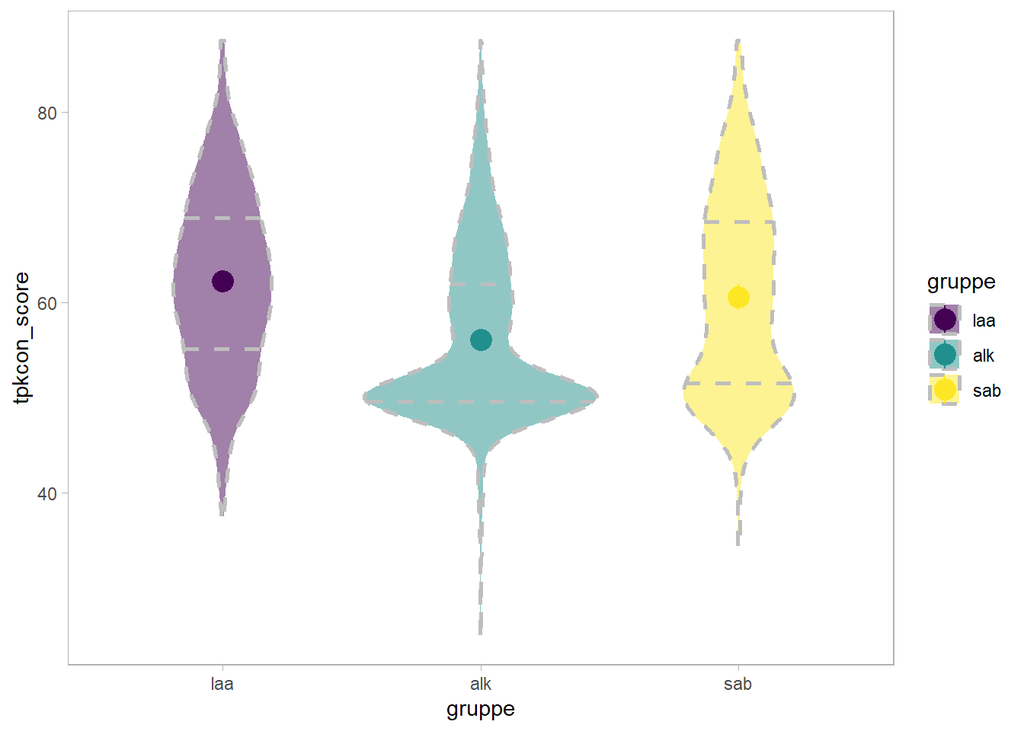

```r
violin_plot(nrw_p,
            eval(p_var),
            eval(p_vergleich))
```

**Deskriptive Ergebnisse**

In der Spalte “group1” wird angezeigt, um welche Gruppe (Nummer der Kohorte oder Gruppe) es sich in der jeweiligen Zeile handelt

```r
psych::describeBy(nrw_p[[p_var]],
                  group = droplevels(nrw_p[[p_vergleich]]),
                  mat=TRUE,
                  digits=3)
```

```
    item group1 vars   n   mean     sd median trimmed    mad    min  max  range
X11    1    laa    1 649 62.211  9.278 62.500  62.080  9.266 37.500 87.5 50.000
X12    2    alk    1 658 56.041  8.733 50.000  54.966  4.633 25.000 87.5 62.500
X13    3    sab    1 200 60.531 10.168 59.375  59.824 13.899 34.375 87.5 53.125
     skew kurtosis    se
X11 0.095   -0.434 0.364
X12 0.857    0.514 0.340
X13 0.328   -0.785 0.719
```

**Kohorten und Gruppen mit Daten**

Anzahl der Teilnehmenden je Gruppe und Kohorte:

```r
nrw %>%
  dplyr::filter(!is.na(get(p_var))) %>%
  {table(.$gruppe, .$kohorte)}
```

```
        1   2   3   4
  laa   0   0   0 649
  alk   0   0   0 658
  sab   0   0   0 200
```

### 2.1.10 TPK: Situationales Wissen

**Abbildung**

```r
rm(p_var)
rm(p_vergleich)
rm(p_kohorten)
rm(p_gruppe)

############################################### #
### Welche VARIABLE soll ausgegeben werden?   ###
############################################### #
p_var <- "tpksit_score" # Variable in Anführungszeichen angeben

############################################### #
### Welcher VERGLEICH soll angestellt werden? ###
############################################### #
p_vergleich <- "gruppe" # Möglich ist: "kohorte" oder "gruppe"

############################################### #
### Welche KOHORTEN sollen ausgegeben werden? ###
############################################### #
# p_kohorten <- c("3", "4") # Verfügbar: "1", "2", "3", "4"
                          # Einfach auskommentieren, wenn
                          # alle ausgegeben werden sollen

############################################### #
### Welche GRUPPEN sollen ausgegeben werden?  ###
############################################### #
# p_gruppe <- c("laa") # Verfügbar: "laa" (Lehramtsanwärter*innen),
                     #            "sab" (Seminarausbilder*innen)
                     #            "alk" (Ausbildungslehrkräfte)
                     # Einfach auskommentieren, wenn
                     # alle ausgegeben werden sollen

nrw_p <- nrw
if (exists("p_kohorten")) {
  nrw_p <- nrw_p |>
    dplyr::filter(kohorte %in% p_kohorten)
}
if (exists("p_gruppe")) {
  nrw_p <- nrw_p |>
    dplyr::filter(gruppe %in% p_gruppe)
}
```

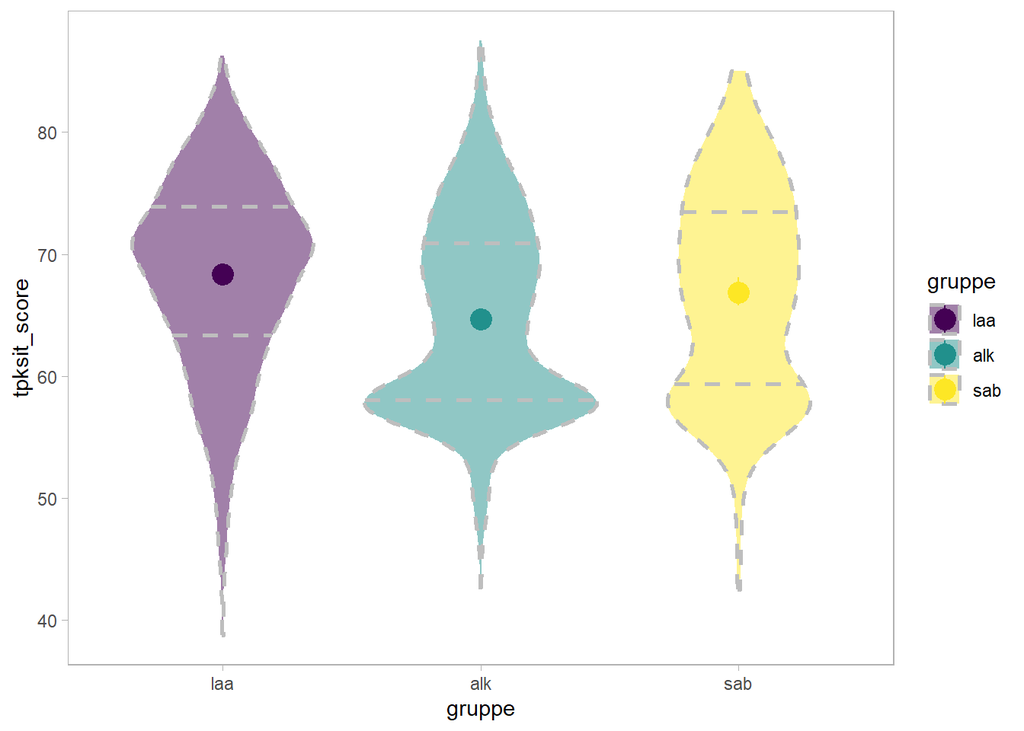

```r
violin_plot(nrw_p,
            eval(p_var),
            eval(p_vergleich))
```

**Deskriptive Ergebnisse**

In der Spalte “group1” wird angezeigt, um welche Gruppe (Nummer der Kohorte oder Gruppe) es sich in der jeweiligen Zeile handelt

```r
psych::describeBy(nrw_p[[p_var]],
                  group = droplevels(nrw_p[[p_vergleich]]),
                  mat=TRUE,
                  digits=3)
```

```
    item group1 vars   n   mean    sd median trimmed    mad   min   max range
X11    1    laa    1 649 68.330 7.811  70.00  68.781  7.413 38.75 86.25  47.5
X12    2    alk    1 658 64.692 7.791  63.75  64.231  9.266 42.50 87.50  45.0
X13    3    sab    1 200 66.844 8.337  67.50  66.609 11.119 42.50 85.00  42.5
      skew kurtosis    se
X11 -0.584    0.210 0.307
X12  0.336   -0.710 0.304
X13  0.003   -0.824 0.590
```

**Kohorten und Gruppen mit Daten**

Anzahl der Teilnehmenden je Gruppe und Kohorte:

```r
nrw %>%
  dplyr::filter(!is.na(get(p_var))) %>%
  {table(.$gruppe, .$kohorte)}
```

```
        1   2   3   4
  laa   0   0   0 649
  alk   0   0   0 658
  sab   0   0   0 200
```

### 2.1.11 TPK: Konzeptuelles Wissen - Subskala Potentiale

**Abbildung**

```r
rm(p_var)
rm(p_vergleich)
rm(p_kohorten)
rm(p_gruppe)

############################################### #
### Welche VARIABLE soll ausgegeben werden?   ###
############################################### #
p_var <- "tpkpot_score" # Variable in Anführungszeichen angeben

############################################### #
### Welcher VERGLEICH soll angestellt werden? ###
############################################### #
p_vergleich <- "gruppe" # Möglich ist: "kohorte" oder "gruppe"

############################################### #
### Welche KOHORTEN sollen ausgegeben werden? ###
############################################### #
# p_kohorten <- c("3", "4") # Verfügbar: "1", "2", "3", "4"
                          # Einfach auskommentieren, wenn
                          # alle ausgegeben werden sollen

############################################### #
### Welche GRUPPEN sollen ausgegeben werden?  ###
############################################### #
# p_gruppe <- c("laa") # Verfügbar: "laa" (Lehramtsanwärter*innen),
                     #            "sab" (Seminarausbilder*innen)
                     #            "alk" (Ausbildungslehrkräfte)
                     # Einfach auskommentieren, wenn
                     # alle ausgegeben werden sollen

nrw_p <- nrw
if (exists("p_kohorten")) {
  nrw_p <- nrw_p |>
    dplyr::filter(kohorte %in% p_kohorten)
}
if (exists("p_gruppe")) {
  nrw_p <- nrw_p |>
    dplyr::filter(gruppe %in% p_gruppe)
}
```

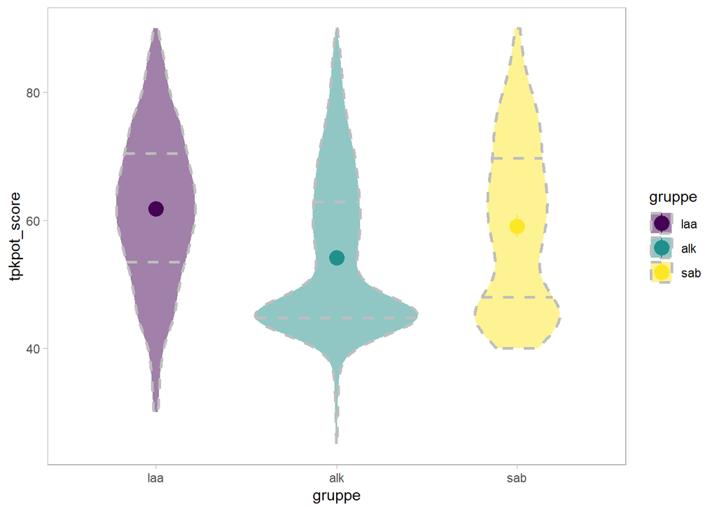

```r
violin_plot(nrw_p,
            eval(p_var),
            eval(p_vergleich))
```

**Deskriptive Ergebnisse**

In der Spalte “group1” wird angezeigt, um welche Gruppe (Nummer der Kohorte oder Gruppe) es sich in der jeweiligen Zeile handelt

```r
psych::describeBy(nrw_p[[p_var]],
                  group = droplevels(nrw_p[[p_vergleich]]),
                  mat=TRUE,
                  digits=3)
```

```
    item group1 vars   n   mean     sd median trimmed    mad min max range
X11    1    laa    1 649 61.834 12.020     60  61.929 14.826  30  90    60
X12    2    alk    1 658 54.179 11.824     50  52.708  7.413  25  90    65
X13    3    sab    1 200 59.100 12.846     60  58.219 22.239  40  90    50
      skew kurtosis    se
X11 -0.134   -0.347 0.472
X12  0.802   -0.297 0.461
X13  0.312   -1.072 0.908
```

**Kohorten und Gruppen mit Daten**

Anzahl der Teilnehmenden je Gruppe und Kohorte:

```r
nrw %>%
  dplyr::filter(!is.na(get(p_var))) %>%
  {table(.$gruppe, .$kohorte)}
```

```
        1   2   3   4
  laa   0   0   0 649
  alk   0   0   0 658
  sab   0   0   0 200
```

**Abbildung**

```r
rm(p_var)
rm(p_vergleich)
rm(p_kohorten)
rm(p_gruppe)

############################################### #
### Welche VARIABLE soll ausgegeben werden?   ###
############################################### #
p_var <- "tpksup_score" # Variable in Anführungszeichen angeben

############################################### #
### Welcher VERGLEICH soll angestellt werden? ###
############################################### #
p_vergleich <- "gruppe" # Möglich ist: "kohorte" oder "gruppe"

############################################### #
### Welche KOHORTEN sollen ausgegeben werden? ###
############################################### #
# p_kohorten <- c("3", "4") # Verfügbar: "1", "2", "3", "4"
                          # Einfach auskommentieren, wenn
                          # alle ausgegeben werden sollen

############################################### #
### Welche GRUPPEN sollen ausgegeben werden?  ###
############################################### #
# p_gruppe <- c("laa") # Verfügbar: "laa" (Lehramtsanwärter*innen),
                     #            "sab" (Seminarausbilder*innen)
                     #            "alk" (Ausbildungslehrkräfte)
                     # Einfach auskommentieren, wenn
                     # alle ausgegeben werden sollen

nrw_p <- nrw
if (exists("p_kohorten")) {
  nrw_p <- nrw_p |>
    dplyr::filter(kohorte %in% p_kohorten)
}
if (exists("p_gruppe")) {
  nrw_p <- nrw_p |>
    dplyr::filter(gruppe %in% p_gruppe)
}
```

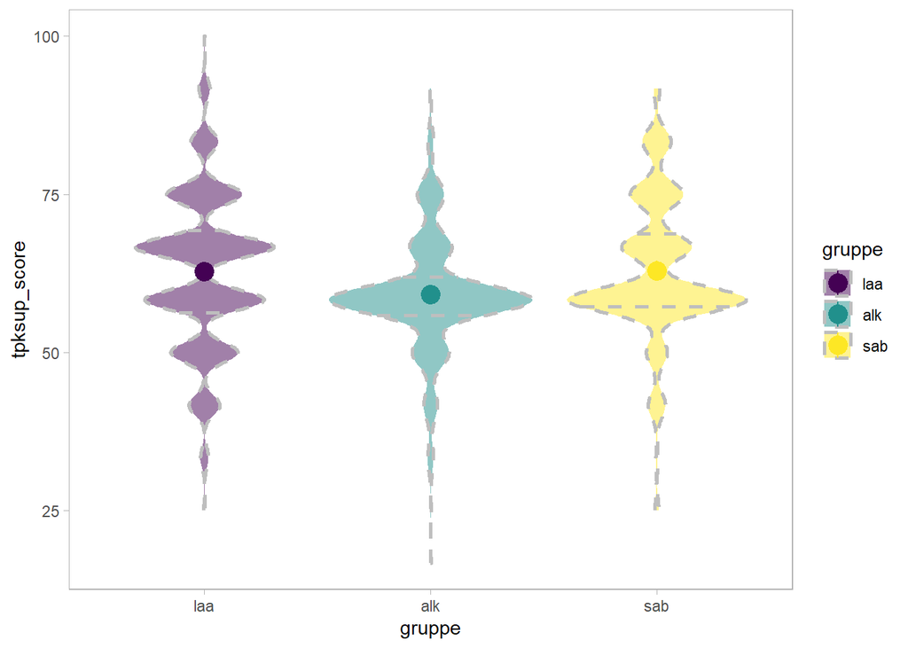

```r
violin_plot(nrw_p,
            eval(p_var),
            eval(p_vergleich))
```

**Deskriptive Ergebnisse**

In der Spalte “group1” wird angezeigt, um welche Gruppe (Nummer der Kohorte oder Gruppe) es sich in der jeweiligen Zeile handelt

```r
psych::describeBy(nrw_p[[p_var]],
                  group = droplevels(nrw_p[[p_vergleich]]),
                  mat=TRUE,
                  digits=3)
```

```
    item group1 vars   n   mean     sd median trimmed    mad    min     max
X11    1    laa    1 649 62.840 12.219 66.667  62.924 12.355 25.000 100.000
X12    2    alk    1 658 59.144  8.914 58.333  58.933  0.000 16.667  91.667
X13    3    sab    1 200 62.917 11.201 58.333  62.812 12.355 25.000  91.667
     range   skew kurtosis    se
X11 75.000 -0.063    0.075 0.480
X12 75.000 -0.007    2.583 0.348
X13 66.667 -0.013    0.921 0.792
```

**Kohorten und Gruppen mit Daten**

Anzahl der Teilnehmenden je Gruppe und Kohorte:

```r
nrw %>%
  dplyr::filter(!is.na(get(p_var))) %>%
  {table(.$gruppe, .$kohorte)}
```

```
        1   2   3   4
  laa   0   0   0 649
  alk   0   0   0 658
  sab   0   0   0 200
```

### 2.1.13 TPK: Situationales Wissen - Subskala AV

**Abbildung**

```r
rm(p_var)
rm(p_vergleich)
rm(p_kohorten)
rm(p_gruppe)

############################################### #
### Welche VARIABLE soll ausgegeben werden?   ###
############################################### #
p_var <- "tpksit_score_av" # Variable in Anführungszeichen angeben

############################################### #
### Welcher VERGLEICH soll angestellt werden? ###
############################################### #
p_vergleich <- "gruppe" # Möglich ist: "kohorte" oder "gruppe"

############################################### #
### Welche KOHORTEN sollen ausgegeben werden? ###
############################################### #
# p_kohorten <- c("3", "4") # Verfügbar: "1", "2", "3", "4"
                          # Einfach auskommentieren, wenn
                          # alle ausgegeben werden sollen

############################################### #
### Welche GRUPPEN sollen ausgegeben werden?  ###
############################################### #
# p_gruppe <- c("laa") # Verfügbar: "laa" (Lehramtsanwärter*innen),
                     #            "sab" (Seminarausbilder*innen)
                     #            "alk" (Ausbildungslehrkräfte)
                     # Einfach auskommentieren, wenn
                     # alle ausgegeben werden sollen

nrw_p <- nrw
if (exists("p_kohorten")) {
  nrw_p <- nrw_p |>
    dplyr::filter(kohorte %in% p_kohorten)
}
if (exists("p_gruppe")) {
  nrw_p <- nrw_p |>
    dplyr::filter(gruppe %in% p_gruppe)
}
```

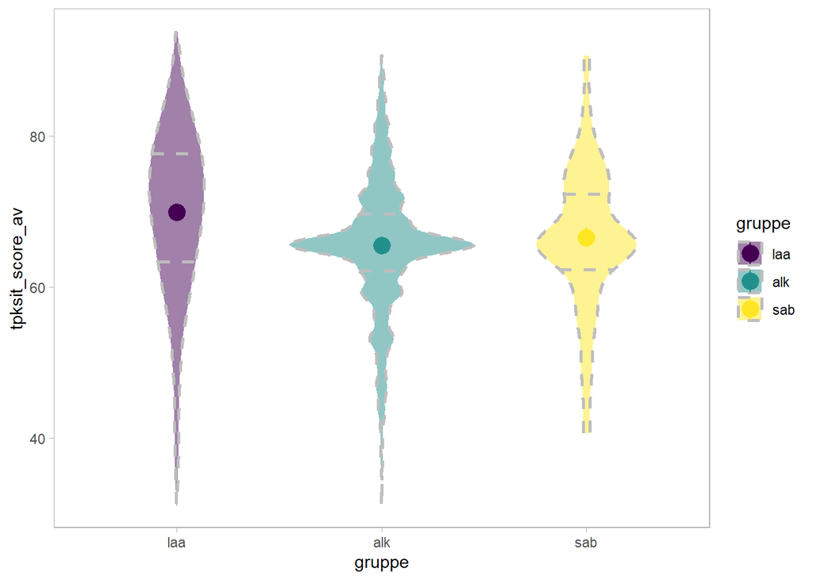

```r
violin_plot(nrw_p,
            eval(p_var),
            eval(p_vergleich))
```

**Deskriptive Ergebnisse**

In der Spalte “group1” wird angezeigt, um welche Gruppe (Nummer der Kohorte oder Gruppe) es sich in der jeweiligen Zeile handelt

```r
psych::describeBy(nrw_p[[p_var]],
                  group = droplevels(nrw_p[[p_vergleich]]),
                  mat=TRUE,
                  digits=3)
```

```
    item group1 vars   n   mean     sd median trimmed   mad    min    max
X11    1    laa    1 649 69.959 10.872 71.875  70.657 9.266 31.250 93.750
X12    2    alk    1 658 65.544  8.543 65.625  65.791 4.633 31.250 90.625
X13    3    sab    1 200 66.562  9.425 65.625  66.914 9.266 40.625 90.625
     range   skew kurtosis    se
X11 62.500 -0.697    0.621 0.427
X12 59.375 -0.382    1.263 0.333
X13 50.000 -0.280    0.791 0.666
```

**Kohorten und Gruppen mit Daten**

Anzahl der Teilnehmenden je Gruppe und Kohorte:

```r
nrw %>%
  dplyr::filter(!is.na(get(p_var))) %>%
  {table(.$gruppe, .$kohorte)}
```

```
        1   2   3   4
  laa   0   0   0 649
  alk   0   0   0 658
  sab   0   0   0 200
```

### 2.1.14 TPK: Situationales Wissen - Subskala TB

**Abbildung**

```r
rm(p_var)
rm(p_vergleich)
rm(p_kohorten)
rm(p_gruppe)

############################################### #
### Welche VARIABLE soll ausgegeben werden?   ###
############################################### #
p_var <- "tpksit_score_tb" # Variable in Anführungszeichen angeben

############################################### #
### Welcher VERGLEICH soll angestellt werden? ###
############################################### #
p_vergleich <- "gruppe" # Möglich ist: "kohorte" oder "gruppe"

############################################### #
### Welche KOHORTEN sollen ausgegeben werden? ###
############################################### #
# p_kohorten <- c("3", "4") # Verfügbar: "1", "2", "3", "4"
                          # Einfach auskommentieren, wenn
                          # alle ausgegeben werden sollen

############################################### #
### Welche GRUPPEN sollen ausgegeben werden?  ###
############################################### #
# p_gruppe <- c("laa") # Verfügbar: "laa" (Lehramtsanwärter*innen),
                     #            "sab" (Seminarausbilder*innen)
                     #            "alk" (Ausbildungslehrkräfte)
                     # Einfach auskommentieren, wenn
                     # alle ausgegeben werden sollen

nrw_p <- nrw
if (exists("p_kohorten")) {
  nrw_p <- nrw_p |>
    dplyr::filter(kohorte %in% p_kohorten)
}
if (exists("p_gruppe")) {
  nrw_p <- nrw_p |>
    dplyr::filter(gruppe %in% p_gruppe)
}
```

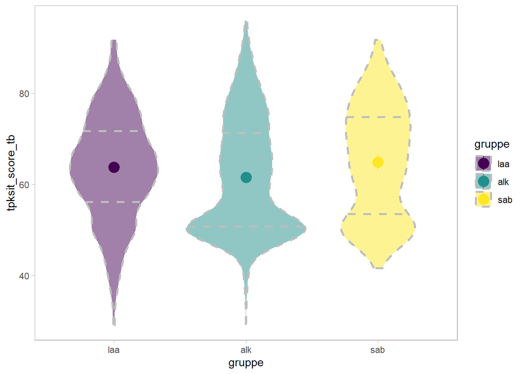

```r
violin_plot(nrw_p,
            eval(p_var),
            eval(p_vergleich))
```

**Deskriptive Ergebnisse**

In der Spalte “group1” wird angezeigt, um welche Gruppe (Nummer der Kohorte oder Gruppe) es sich in der jeweiligen Zeile handelt

```r
psych::describeBy(nrw_p[[p_var]],
                  group = droplevels(nrw_p[[p_vergleich]]),
                  mat=TRUE,
                  digits=3)
```

```
    item group1 vars   n   mean     sd median trimmed    mad    min    max
X11    1    laa    1 649 63.739 11.399 62.500  63.948 12.355 29.167 91.667
X12    2    alk    1 658 61.575 12.300 58.333  60.519 12.355 29.167 95.833
X13    3    sab    1 200 64.875 12.038 66.667  64.453 18.532 41.667 91.667
     range   skew kurtosis    se
X11 62.500 -0.157   -0.192 0.447
X12 66.667  0.510   -0.757 0.480
X13 50.000  0.075   -1.186 0.851
```

**Kohorten und Gruppen mit Daten**

Anzahl der Teilnehmenden je Gruppe und Kohorte:

```r
nrw %>%
  dplyr::filter(!is.na(get(p_var))) %>%
  {table(.$gruppe, .$kohorte)}
```

```
        1   2   3   4
  laa   0   0   0 649
  alk   0   0   0 658
  sab   0   0   0 200
```

### 2.1.15 TPK: Situationales Wissen - Subskala AA

**Abbildung**

```r
rm(p_var)
rm(p_vergleich)
rm(p_kohorten)
rm(p_gruppe)

############################################### #
### Welche VARIABLE soll ausgegeben werden?   ###
############################################### #
p_var <- "tpksit_score_aa" # Variable in Anführungszeichen angeben

############################################### #
### Welcher VERGLEICH soll angestellt werden? ###
############################################### #
p_vergleich <- "gruppe" # Möglich ist: "kohorte" oder "gruppe"

############################################### #
### Welche KOHORTEN sollen ausgegeben werden? ###
############################################### #
# p_kohorten <- c("3", "4") # Verfügbar: "1", "2", "3", "4"
                          # Einfach auskommentieren, wenn
                          # alle ausgegeben werden sollen

############################################### #
### Welche GRUPPEN sollen ausgegeben werden?  ###
############################################### #
# p_gruppe <- c("laa") # Verfügbar: "laa" (Lehramtsanwärter*innen),
                     #            "sab" (Seminarausbilder*innen)
                     #            "alk" (Ausbildungslehrkräfte)
                     # Einfach auskommentieren, wenn
                     # alle ausgegeben werden sollen

nrw_p <- nrw
if (exists("p_kohorten")) {
  nrw_p <- nrw_p |>
    dplyr::filter(kohorte %in% p_kohorten)
}
if (exists("p_gruppe")) {
  nrw_p <- nrw_p |>
    dplyr::filter(gruppe %in% p_gruppe)
}
```

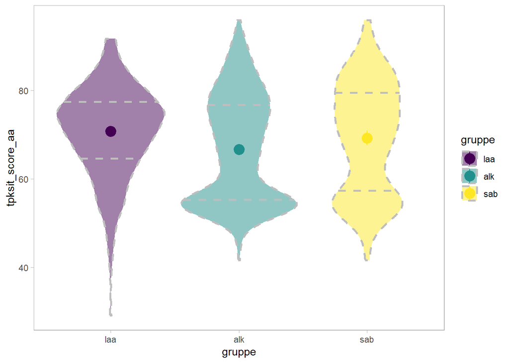

```r
violin_plot(nrw_p,
            eval(p_var),
            eval(p_vergleich))
```

**Deskriptive Ergebnisse**

In der Spalte “group1” wird angezeigt, um welche Gruppe (Nummer der Kohorte oder Gruppe) es sich in der jeweiligen Zeile handelt

```r
psych::describeBy(nrw_p[[p_var]],
                  group = droplevels(nrw_p[[p_vergleich]]),
                  mat=TRUE,
                  digits=3)
```

```
    item group1 vars   n   mean     sd median trimmed    mad    min    max
X11    1    laa    1 649 70.750 10.027 70.833  71.329 12.355 29.167 91.667
X12    2    alk    1 658 66.673 11.991 66.667  65.862 18.532 41.667 95.833
X13    3    sab    1 200 69.188 12.454 70.833  69.036 18.532 41.667 95.833
     range   skew kurtosis    se
X11 62.500 -0.643    0.745 0.394
X12 54.167  0.292   -1.195 0.467
X13 54.167 -0.070   -1.141 0.881
```

**Kohorten und Gruppen mit Daten**

Anzahl der Teilnehmenden je Gruppe und Kohorte:

```r
nrw %>%
  dplyr::filter(!is.na(get(p_var))) %>%
  {table(.$gruppe, .$kohorte)}
```

```
        1   2   3   4
  laa   0   0   0 649
  alk   0   0   0 658
  sab   0   0   0 200
```

## 2.2 Vorbereitungsdienst aus Sicht der LAA

### 2.2.1 Emotionale Erschöpfung

**Abbildung**

```r
rm(p_var)
rm(p_vergleich)
rm(p_kohorten)
rm(p_gruppe)

############################################### #
### Welche VARIABLE soll ausgegeben werden?   ###
############################################### #
p_var <- "bel" # Variable in Anführungszeichen angeben

############################################### #
### Welcher VERGLEICH soll angestellt werden? ###
############################################### #
p_vergleich <- "interaction(gruppe, kohorte)" # Möglich ist: "kohorte", "gruppe" oder "interaction(gruppe, kohorte)"

############################################### #
### Welche KOHORTEN sollen ausgegeben werden? ###
############################################### #
# p_kohorten <- c("3", "4") # Verfügbar: "1", "2", "3", "4"
                          # Einfach auskommentieren, wenn
                          # alle ausgegeben werden sollen

############################################### #
### Welche GRUPPEN sollen ausgegeben werden?  ###
############################################### #
# p_gruppe <- c("laa") # Verfügbar: "laa" (Lehramtsanwärter*innen),
                     #            "sab" (Seminarausbilder*innen)
                     #            "alk" (Ausbildungslehrkräfte)
                     # Einfach auskommentieren, wenn
                     # alle ausgegeben werden sollen

nrw_p <- nrw
if (exists("p_kohorten")) {
  nrw_p <- nrw_p |>
    dplyr::filter(kohorte %in% p_kohorten)
}
if (exists("p_gruppe")) {
  nrw_p <- nrw_p |>
    dplyr::filter(gruppe %in% p_gruppe)
}
```

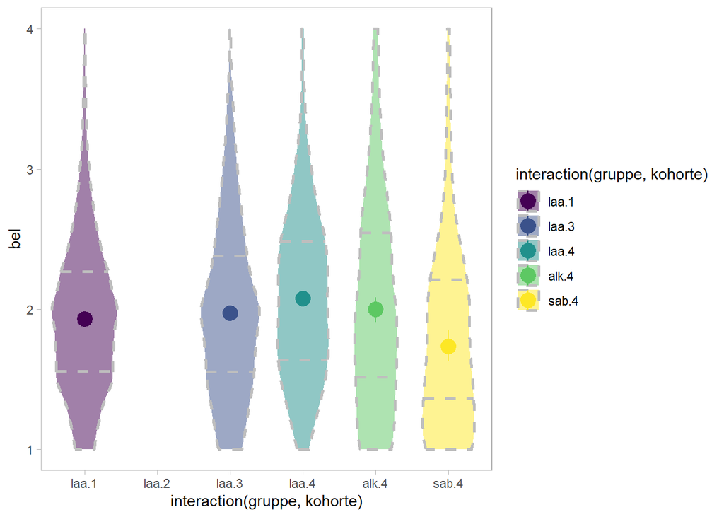

```r
violin_plot(nrw_p,
            eval(p_var),
            eval(p_vergleich))
```

**Deskriptive Ergebnisse**

In der Spalte “group1” wird angezeigt, um welche Gruppe (Nummer der Kohorte oder Gruppe) es sich in der jeweiligen Zeile handelt

```r
psych::describeBy(nrw_p[[p_var]],
                  # group = ifelse(grepl("interaction", p_vergleich, fixed = T),    # TO FIX
                  #                interaction(nrw_p$gruppe[!is.na(nrw_p[[p_var]])],
                  #                            nrw_p$kohorte[!is.na(nrw_p[[p_var]])]),
                  #                droplevels(nrw_p[[p_vergleich]])),
                  group = droplevels(interaction(nrw_p$gruppe, nrw_p$kohorte)),
                  mat=TRUE,
                  digits=3)
```

```
    item group1 vars    n  mean    sd median trimmed   mad min  max range  skew
X11    1  laa.1    1 1025 1.929 0.545    2.0   1.897 0.494   1    4     3 0.622
X12    2  laa.2    1    0   NaN    NA     NA     NaN    NA Inf -Inf  -Inf    NA
X13    3  laa.3    1  649 1.972 0.619    2.0   1.933 0.741   1    4     3 0.553
X14    4  laa.4    1  580 2.075 0.593    2.0   2.050 0.741   1    4     3 0.447
X15    5  alk.4    1  303 1.998 0.745    2.0   1.940 0.741   1    4     3 0.584
X16    6  sab.4    1  123 1.736 0.650    1.5   1.662 0.741   1    4     3 0.947
    kurtosis    se
X11    0.633 0.017
X12       NA    NA
X13   -0.010 0.024
X14    0.045 0.025
X15   -0.280 0.043
X16    0.804 0.059
```

**Kohorten und Gruppen mit Daten**

Anzahl der Teilnehmenden je Gruppe und Kohorte:

```r
nrw %>%
  dplyr::filter(!is.na(get(p_var))) %>%
  {table(.$gruppe, .$kohorte)}
```

```
         1    2    3    4
  laa 1025    0  649  580
  alk    0    0    0  303
  sab    0    0    0  123
```

### 2.2.2 Arbeitsengagement

**Abbildung**

```r
rm(p_var)
rm(p_vergleich)
rm(p_kohorten)
rm(p_gruppe)

############################################### #
### Welche VARIABLE soll ausgegeben werden?   ###
############################################### #
p_var <- "aen" # Variable in Anführungszeichen angeben

############################################### #
### Welcher VERGLEICH soll angestellt werden? ###
############################################### #
p_vergleich <- "interaction(gruppe, kohorte)" # Möglich ist: "kohorte", "gruppe" oder "interaction(gruppe, kohorte)"

############################################### #
### Welche KOHORTEN sollen ausgegeben werden? ###
############################################### #
# p_kohorten <- c("3", "4") # Verfügbar: "1", "2", "3", "4"
                          # Einfach auskommentieren, wenn
                          # alle ausgegeben werden sollen

############################################### #
### Welche GRUPPEN sollen ausgegeben werden?  ###
############################################### #
# p_gruppe <- c("laa") # Verfügbar: "laa" (Lehramtsanwärter*innen),
                     #            "sab" (Seminarausbilder*innen)
                     #            "alk" (Ausbildungslehrkräfte)
                     # Einfach auskommentieren, wenn
                     # alle ausgegeben werden sollen

nrw_p <- nrw
if (exists("p_kohorten")) {
  nrw_p <- nrw_p |>
    dplyr::filter(kohorte %in% p_kohorten)
}
if (exists("p_gruppe")) {
  nrw_p <- nrw_p |>
    dplyr::filter(gruppe %in% p_gruppe)
}
```

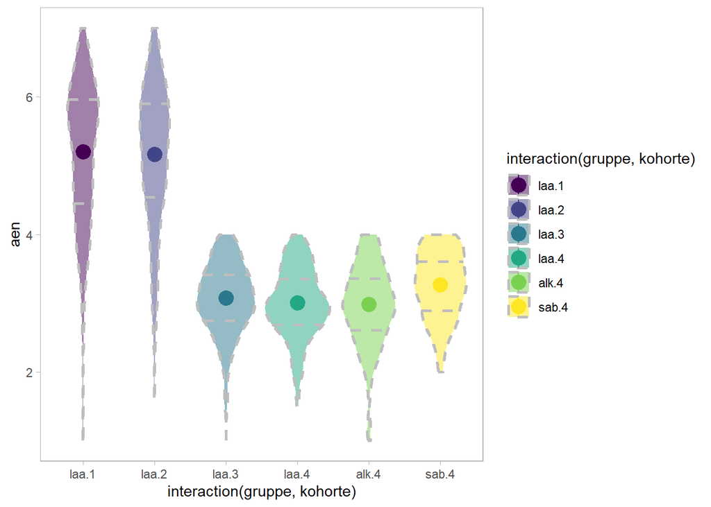

```r
violin_plot(nrw_p,
            eval(p_var),
            eval(p_vergleich))
```

**Deskriptive Ergebnisse**

In der Spalte “group1” wird angezeigt, um welche Gruppe (Nummer der Kohorte oder Gruppe) es sich in der jeweiligen Zeile handelt

```r
psych::describeBy(nrw_p[[p_var]],
                  # group = ifelse(grepl("interaction", p_vergleich, fixed = T),    # TO FIX
                  #                interaction(nrw_p$gruppe[!is.na(nrw_p[[p_var]])],
                  #                            nrw_p$kohorte[!is.na(nrw_p[[p_var]])]),
                  #                droplevels(nrw_p[[p_vergleich]])),
                  group = droplevels(interaction(nrw_p$gruppe, nrw_p$kohorte)),
                  mat=TRUE,
                  digits=3)
```

```
    item group1 vars   n  mean    sd median trimmed   mad   min max range
X11    1  laa.1    1 493 5.203 1.007  5.375   5.261 1.112 1.000   7 6.000
X12    2  laa.2    1 490 5.167 1.024  5.375   5.242 0.927 1.625   7 5.375
X13    3  laa.3    1 647 3.074 0.504  3.125   3.095 0.556 1.000   4 3.000
X14    4  laa.4    1 580 3.007 0.497  3.000   3.021 0.556 1.500   4 2.500
X15    5  alk.4    1 302 2.982 0.584  3.000   3.006 0.556 1.000   4 3.000
X16    6  sab.4    1 124 3.269 0.488  3.250   3.295 0.556 2.000   4 2.000
      skew kurtosis    se
X11 -0.607    0.059 0.045
X12 -0.673    0.212 0.046
X13 -0.486    0.408 0.020
X14 -0.227   -0.157 0.021
X15 -0.600    0.806 0.034
X16 -0.395   -0.587 0.044
```

**Kohorten und Gruppen mit Daten**

Anzahl der Teilnehmenden je Gruppe und Kohorte:

```r
nrw %>%
  dplyr::filter(!is.na(get(p_var))) %>%
  {table(.$gruppe, .$kohorte)}
```

```
        1   2   3   4
  laa 493 490 647 580
  alk   0   0   0 302
  sab   0   0   0 124
```

### 2.2.3 Berufszufriedenheit

**Abbildung**

```r
rm(p_var)
rm(p_vergleich)
rm(p_kohorten)
rm(p_gruppe)

############################################### #
### Welche VARIABLE soll ausgegeben werden?   ###
############################################### #
p_var <- "zfr" # Variable in Anführungszeichen angeben

############################################### #
### Welcher VERGLEICH soll angestellt werden? ###
############################################### #
p_vergleich <- "interaction(gruppe, kohorte)" # Möglich ist: "kohorte", "gruppe" oder "interaction(gruppe, kohorte)"

############################################### #
### Welche KOHORTEN sollen ausgegeben werden? ###
############################################### #
# p_kohorten <- c("3", "4") # Verfügbar: "1", "2", "3", "4"
                          # Einfach auskommentieren, wenn
                          # alle ausgegeben werden sollen

############################################### #
### Welche GRUPPEN sollen ausgegeben werden?  ###
############################################### #
# p_gruppe <- c("laa") # Verfügbar: "laa" (Lehramtsanwärter*innen),
                     #            "sab" (Seminarausbilder*innen)
                     #            "alk" (Ausbildungslehrkräfte)
                     # Einfach auskommentieren, wenn
                     # alle ausgegeben werden sollen

nrw_p <- nrw
if (exists("p_kohorten")) {
  nrw_p <- nrw_p |>
    dplyr::filter(kohorte %in% p_kohorten)
}
if (exists("p_gruppe")) {
  nrw_p <- nrw_p |>
    dplyr::filter(gruppe %in% p_gruppe)
}
```

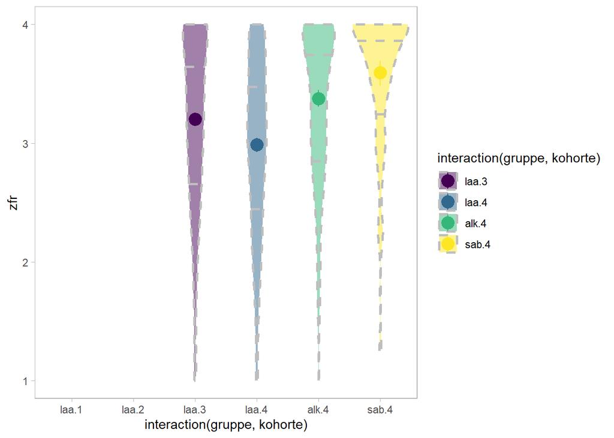

```r
violin_plot(nrw_p,
            eval(p_var),
            eval(p_vergleich))
```

**Deskriptive Ergebnisse**

In der Spalte “group1” wird angezeigt, um welche Gruppe (Nummer der Kohorte oder Gruppe) es sich in der jeweiligen Zeile handelt

```r
psych::describeBy(nrw_p[[p_var]],
                  # group = ifelse(grepl("interaction", p_vergleich, fixed = T),    # TO FIX
                  #                interaction(nrw_p$gruppe[!is.na(nrw_p[[p_var]])],
                  #                            nrw_p$kohorte[!is.na(nrw_p[[p_var]])]),
                  #                droplevels(nrw_p[[p_vergleich]])),
                  group = droplevels(interaction(nrw_p$gruppe, nrw_p$kohorte)),
                  mat=TRUE,
                  digits=3)
```

```
    item group1 vars   n  mean    sd median trimmed   mad  min  max range
X11    1  laa.1    1   0   NaN    NA     NA     NaN    NA  Inf -Inf  -Inf
X12    2  laa.2    1   0   NaN    NA     NA     NaN    NA  Inf -Inf  -Inf
X13    3  laa.3    1 644 3.201 0.714   3.25   3.282 0.741 1.00    4  3.00
X14    4  laa.4    1 580 2.986 0.739   3.00   3.036 0.741 1.00    4  3.00
X15    5  alk.4    1 303 3.376 0.635   3.50   3.463 0.741 1.00    4  3.00
X16    6  sab.4    1 125 3.592 0.576   3.75   3.710 0.371 1.25    4  2.75
      skew kurtosis    se
X11     NA       NA    NA
X12     NA       NA    NA
X13 -0.833    0.172 0.028
X14 -0.564   -0.282 0.031
X15 -0.990    0.419 0.036
X16 -1.922    3.819 0.052
```

**Kohorten und Gruppen mit Daten**

Anzahl der Teilnehmenden je Gruppe und Kohorte:

```r
nrw %>%
  dplyr::filter(!is.na(get(p_var))) %>%
  {table(.$gruppe, .$kohorte)}
```

```
        1   2   3   4
  laa   0   0 644 580
  alk   0   0   0 303
  sab   0   0   0 125
```

## 2.3 Beurteilung der Ausbildungssituation im VD

### 2.3.1 Überzeugungen: Transmissiv

**Abbildung**

```r
rm(p_var)
rm(p_vergleich)
rm(p_kohorten)
rm(p_gruppe)

############################################### #
### Welche VARIABLE soll ausgegeben werden?   ###
############################################### #
p_var <- "uebr" # Variable in Anführungszeichen angeben

############################################### #
### Welcher VERGLEICH soll angestellt werden? ###
############################################### #
p_vergleich <- "interaction(gruppe, kohorte)" # Möglich ist: "kohorte", "gruppe" oder
# to fix: diese Zeile fehlt in manchen Variablen

############################################### #
### Welche KOHORTEN sollen ausgegeben werden? ###
############################################### #
# p_kohorten <- c("3", "4") # Verfügbar: "1", "2", "3", "4"
                          # Einfach auskommentieren, wenn
                          # alle ausgegeben werden sollen

############################################### #
### Welche GRUPPEN sollen ausgegeben werden?  ###
############################################### #
# p_gruppe <- c("laa") # Verfügbar: "laa" (Lehramtsanwärter*innen),
                     #            "sab" (Seminarausbilder*innen)
                     #            "alk" (Ausbildungslehrkräfte)
                     # Einfach auskommentieren, wenn
                     # alle ausgegeben werden sollen

nrw_p <- nrw
if (exists("p_kohorten")) {
  nrw_p <- nrw_p |>
    dplyr::filter(kohorte %in% p_kohorten)
}
if (exists("p_gruppe")) {
  nrw_p <- nrw_p |>
    dplyr::filter(gruppe %in% p_gruppe)
}
```

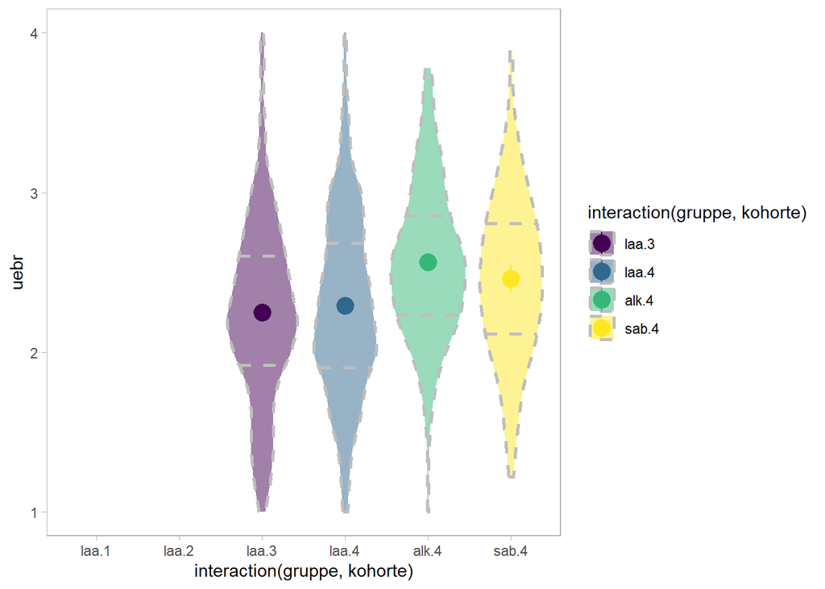

```r
violin_plot(nrw_p,
            eval(p_var),
            eval(p_vergleich))
```

**Deskriptive Ergebnisse**

In der Spalte “group1” wird angezeigt, um welche Gruppe (Nummer der Kohorte oder Gruppe) es sich in der jeweiligen Zeile handelt

```r
psych::describeBy(nrw_p[[p_var]],
                  group = droplevels(interaction(nrw_p$gruppe, nrw_p$kohorte)), # to fix
                  mat=TRUE,
                  digits=3)
```

```
    item group1 vars   n  mean    sd median trimmed   mad   min   max range
X11    1  laa.1    1   0   NaN    NA     NA     NaN    NA   Inf  -Inf  -Inf
X12    2  laa.2    1   0   NaN    NA     NA     NaN    NA   Inf  -Inf  -Inf
X13    3  laa.3    1 658 2.251 0.563  2.200   2.246 0.593 1.000 4.000 3.000
X14    4  laa.4    1 623 2.291 0.566  2.200   2.278 0.593 1.000 4.000 3.000
X15    5  alk.4    1 311 2.563 0.466  2.556   2.550 0.494 1.000 3.778 2.778
X16    6  sab.4    1 127 2.461 0.499  2.444   2.463 0.494 1.222 3.889 2.667
     skew kurtosis    se
X11    NA       NA    NA
X12    NA       NA    NA
X13 0.198    0.323 0.022
X14 0.297   -0.004 0.023
X15 0.200    0.165 0.026
X16 0.064   -0.016 0.044
```

**Kohorten und Gruppen mit Daten**

Anzahl der Teilnehmenden je Gruppe und Kohorte:

```r
nrw %>%
  dplyr::filter(!is.na(get(p_var))) %>%
  {table(.$gruppe, .$kohorte)}
```

```
        1   2   3   4
  laa   0   0 658 623
  alk   0   0   0 311
  sab   0   0   0 127
```

### 2.3.2 Überzeugungen: Konstruktivistisch

**Abbildung**

```r
rm(p_var)
rm(p_vergleich)
rm(p_kohorten)
rm(p_gruppe)

############################################### #
### Welche VARIABLE soll ausgegeben werden?   ###
############################################### #
p_var <- "uebk" # Variable in Anführungszeichen angeben

############################################### #
### Welcher VERGLEICH soll angestellt werden? ###
############################################### #
p_vergleich <- "interaction(gruppe, kohorte)" # Möglich ist: "kohorte", "gruppe" oder

############################################### #
### Welche KOHORTEN sollen ausgegeben werden? ###
############################################### #
# p_kohorten <- c("3", "4") # Verfügbar: "1", "2", "3", "4"
                          # Einfach auskommentieren, wenn
                          # alle ausgegeben werden sollen

############################################### #
### Welche GRUPPEN sollen ausgegeben werden?  ###
############################################### #
# p_gruppe <- c("laa") # Verfügbar: "laa" (Lehramtsanwärter*innen),
                     #            "sab" (Seminarausbilder*innen)
                     #            "alk" (Ausbildungslehrkräfte)
                     # Einfach auskommentieren, wenn
                     # alle ausgegeben werden sollen

nrw_p <- nrw
if (exists("p_kohorten")) {
  nrw_p <- nrw_p |>
    dplyr::filter(kohorte %in% p_kohorten)
}
if (exists("p_gruppe")) {
  nrw_p <- nrw_p |>
    dplyr::filter(gruppe %in% p_gruppe)
}
```

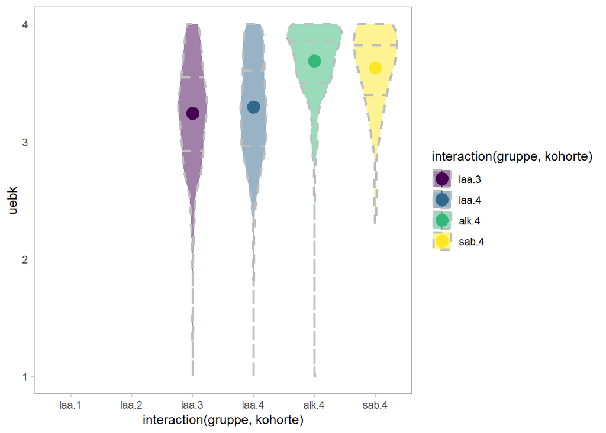

```r
violin_plot(nrw_p,
            eval(p_var),
            eval(p_vergleich))
```

**Deskriptive Ergebnisse**

In der Spalte “group1” wird angezeigt, um welche Gruppe (Nummer der Kohorte oder Gruppe) es sich in der jeweiligen Zeile handelt

```r
psych::describeBy(nrw_p[[p_var]],
                  group = droplevels(interaction(nrw_p$gruppe, nrw_p$kohorte)), # to fix
                  mat=TRUE,
                  digits=3)
```

```
    item group1 vars   n  mean    sd median trimmed   mad min  max range   skew
X11    1  laa.1    1   0   NaN    NA     NA     NaN    NA Inf -Inf  -Inf     NA
X12    2  laa.2    1   0   NaN    NA     NA     NaN    NA Inf -Inf  -Inf     NA
X13    3  laa.3    1 659 3.241 0.474  3.286   3.265 0.424 1.0    4   3.0 -0.819
X14    4  laa.4    1 623 3.293 0.461  3.286   3.315 0.424 1.0    4   3.0 -0.665
X15    5  alk.4    1 311 3.685 0.319  3.778   3.730 0.264 1.0    4   3.0 -2.649
X16    6  sab.4    1 127 3.627 0.339  3.700   3.670 0.297 2.3    4   1.7 -1.296
    kurtosis    se
X11       NA    NA
X12       NA    NA
X13    1.807 0.018
X14    1.241 0.018
X15   15.651 0.018
X16    1.993 0.030
```

**Kohorten und Gruppen mit Daten**

Anzahl der Teilnehmenden je Gruppe und Kohorte:

```r
nrw %>%
  dplyr::filter(!is.na(get(p_var))) %>%
  {table(.$gruppe, .$kohorte)}
```

```
        1   2   3   4
  laa   0   0 659 623
  alk   0   0   0 311
  sab   0   0   0 127
```

### 2.3.3 Wahrg. Integration von Theorie & Praxis im Studienseminar

**Abbildung**

```r
rm(p_var)
rm(p_vergleich)
rm(p_kohorten)
rm(p_gruppe)

############################################### #
### Welche VARIABLE soll ausgegeben werden?   ###
############################################### #
p_var <- "TPZU" # Variable in Anführungszeichen angeben

############################################### #
### Welcher VERGLEICH soll angestellt werden? ###
############################################### #
p_vergleich <- "gruppe" # Möglich ist: "kohorte" oder "gruppe"

############################################### #
### Welche KOHORTEN sollen ausgegeben werden? ###
############################################### #
# p_kohorten <- c("3", "4") # Verfügbar: "1", "2", "3", "4"
                          # Einfach auskommentieren, wenn
                          # alle ausgegeben werden sollen

############################################### #
### Welche GRUPPEN sollen ausgegeben werden?  ###
############################################### #
# p_gruppe <- c("laa") # Verfügbar: "laa" (Lehramtsanwärter*innen),
                     #            "sab" (Seminarausbilder*innen)
                     #            "alk" (Ausbildungslehrkräfte)
                     # Einfach auskommentieren, wenn
                     # alle ausgegeben werden sollen

nrw_p <- nrw
if (exists("p_kohorten")) {
  nrw_p <- nrw_p |>
    dplyr::filter(kohorte %in% p_kohorten)
}
if (exists("p_gruppe")) {
  nrw_p <- nrw_p |>
    dplyr::filter(gruppe %in% p_gruppe)
}
```

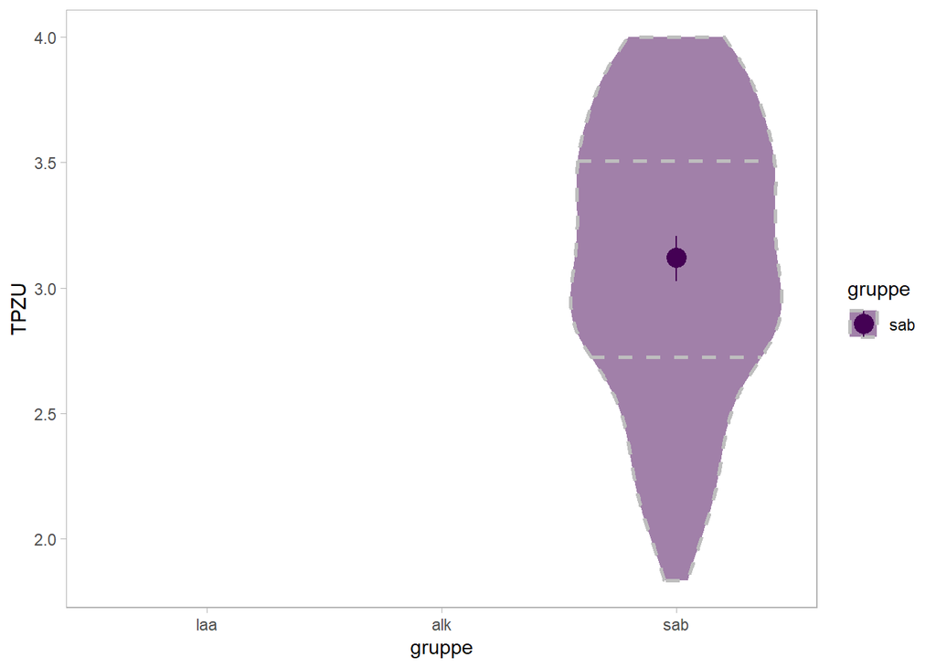

```r
violin_plot(nrw_p,
            eval(p_var),
            eval(p_vergleich))
```

**Deskriptive Ergebnisse**

In der Spalte “group1” wird angezeigt, um welche Gruppe (Nummer der Kohorte oder Gruppe) es sich in der jeweiligen Zeile handelt

```r
psych::describeBy(nrw_p[[p_var]],
                  group = droplevels(nrw_p[[p_vergleich]]),
                  mat=TRUE,
                  digits=3)
```

```
    item group1 vars   n  mean   sd median trimmed   mad   min  max range
X11    1    laa    1   0   NaN   NA     NA     NaN    NA   Inf -Inf  -Inf
X12    2    alk    1   0   NaN   NA     NA     NaN    NA   Inf -Inf  -Inf
X13    3    sab    1 125 3.121 0.54  3.167   3.143 0.494 1.833    4 2.167
      skew kurtosis    se
X11     NA       NA    NA
X12     NA       NA    NA
X13 -0.273   -0.753 0.048
```

**Kohorten und Gruppen mit Daten**

Anzahl der Teilnehmenden je Gruppe und Kohorte:

```r
nrw %>%
  dplyr::filter(!is.na(get(p_var))) %>%
  {table(.$gruppe, .$kohorte)}
```

```
        1   2   3   4
  laa   0   0   0   0
  alk   0   0   0   0
  sab   0   0   0 125
```

### 2.3.4 Innovationsbereitschaft

**Abbildung**

```r
rm(p_var)
rm(p_vergleich)
rm(p_kohorten)
rm(p_gruppe)

############################################### #
### Welche VARIABLE soll ausgegeben werden?   ###
############################################### #
p_var <- "INNO" # Variable in Anführungszeichen angeben

############################################### #
### Welcher VERGLEICH soll angestellt werden? ###
############################################### #
p_vergleich <- "gruppe" # Möglich ist: "kohorte" oder "gruppe"

############################################### #
### Welche KOHORTEN sollen ausgegeben werden? ###
############################################### #
# p_kohorten <- c("3", "4") # Verfügbar: "1", "2", "3", "4"
                          # Einfach auskommentieren, wenn
                          # alle ausgegeben werden sollen

############################################### #
### Welche GRUPPEN sollen ausgegeben werden?  ###
############################################### #
# p_gruppe <- c("laa") # Verfügbar: "laa" (Lehramtsanwärter*innen),
                     #            "sab" (Seminarausbilder*innen)
                     #            "alk" (Ausbildungslehrkräfte)
                     # Einfach auskommentieren, wenn
                     # alle ausgegeben werden sollen

nrw_p <- nrw
if (exists("p_kohorten")) {
  nrw_p <- nrw_p |>
    dplyr::filter(kohorte %in% p_kohorten)
}
if (exists("p_gruppe")) {
  nrw_p <- nrw_p |>
    dplyr::filter(gruppe %in% p_gruppe)
}
```

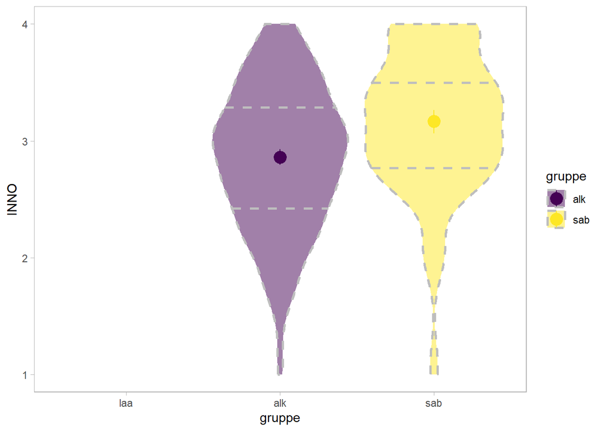

```r
violin_plot(nrw_p,
            eval(p_var),
            eval(p_vergleich))
```

**Deskriptive Ergebnisse**

In der Spalte “group1” wird angezeigt, um welche Gruppe (Nummer der Kohorte oder Gruppe) es sich in der jeweiligen Zeile handelt

```r
psych::describeBy(nrw_p[[p_var]],
                  group = droplevels(nrw_p[[p_vergleich]]),
                  mat=TRUE,
                  digits=3)
```

```
    item group1 vars   n  mean    sd median trimmed   mad min  max range   skew
X11    1    laa    1   0   NaN    NA     NA     NaN    NA Inf -Inf  -Inf     NA
X12    2    alk    1 304 2.860 0.609  3.000   2.881 0.741   1    4     3 -0.323
X13    3    sab    1 122 3.167 0.589  3.167   3.206 0.494   1    4     3 -0.753
    kurtosis    se
X11       NA    NA
X12   -0.243 0.035
X13    1.147 0.053
```

**Kohorten und Gruppen mit Daten**

Anzahl der Teilnehmenden je Gruppe und Kohorte:

```r
nrw %>%
  dplyr::filter(!is.na(get(p_var))) %>%
  {table(.$gruppe, .$kohorte)}
```

```
        1   2   3   4
  laa   0   0   0   0
  alk   0   0   0 304
  sab   0   0   0 122
```

### 2.3.5 Externale Kontrollüberzeugungen

**Abbildung**

```r
rm(p_var)
rm(p_vergleich)
rm(p_kohorten)
rm(p_gruppe)

############################################### #
### Welche VARIABLE soll ausgegeben werden?   ###
############################################### #
p_var <- "EXKO" # Variable in Anführungszeichen angeben

############################################### #
### Welcher VERGLEICH soll angestellt werden? ###
############################################### #
p_vergleich <- "gruppe" # Möglich ist: "kohorte" oder "gruppe"

############################################### #
### Welche KOHORTEN sollen ausgegeben werden? ###
############################################### #
# p_kohorten <- c("3", "4") # Verfügbar: "1", "2", "3", "4"
                          # Einfach auskommentieren, wenn
                          # alle ausgegeben werden sollen

############################################### #
### Welche GRUPPEN sollen ausgegeben werden?  ###
############################################### #
# p_gruppe <- c("laa") # Verfügbar: "laa" (Lehramtsanwärter*innen),
                     #            "sab" (Seminarausbilder*innen)
                     #            "alk" (Ausbildungslehrkräfte)
                     # Einfach auskommentieren, wenn
                     # alle ausgegeben werden sollen

nrw_p <- nrw
if (exists("p_kohorten")) {
  nrw_p <- nrw_p |>
    dplyr::filter(kohorte %in% p_kohorten)
}
if (exists("p_gruppe")) {
  nrw_p <- nrw_p |>
    dplyr::filter(gruppe %in% p_gruppe)
}
```

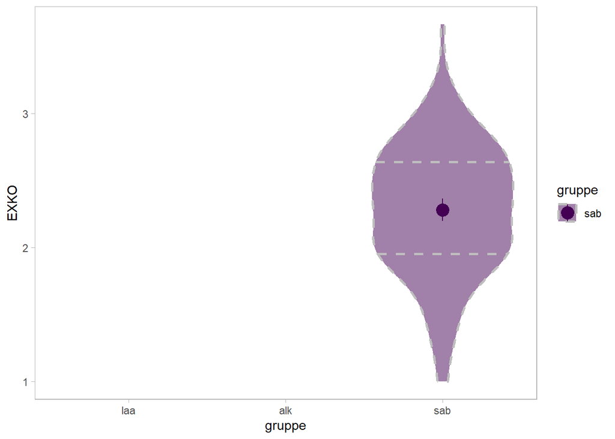

```r
violin_plot(nrw_p,
            eval(p_var),
            eval(p_vergleich))
```

**Deskriptive Ergebnisse**

In der Spalte “group1” wird angezeigt, um welche Gruppe (Nummer der Kohorte oder Gruppe) es sich in der jeweiligen Zeile handelt

```r
psych::describeBy(nrw_p[[p_var]],
                  group = droplevels(nrw_p[[p_vergleich]]),
                  mat=TRUE,
                  digits=3)
```

```
    item group1 vars   n  mean    sd median trimmed   mad min   max range
X11    1    laa    1   0   NaN    NA     NA     NaN    NA Inf  -Inf  -Inf
X12    2    alk    1   0   NaN    NA     NA     NaN    NA Inf  -Inf  -Inf
X13    3    sab    1 124 2.283 0.479  2.333   2.297 0.494   1 3.667 2.667
      skew kurtosis    se
X11     NA       NA    NA
X12     NA       NA    NA
X13 -0.197    0.023 0.043
```

**Kohorten und Gruppen mit Daten**

Anzahl der Teilnehmenden je Gruppe und Kohorte:

```r
nrw %>%
  dplyr::filter(!is.na(get(p_var))) %>%
  {table(.$gruppe, .$kohorte)}
```

```
        1   2   3   4
  laa   0   0   0   0
  alk   0   0   0   0
  sab   0   0   0 124
```

### 2.3.6 Intention to Quit

**Abbildung**

```r
rm(p_var)
rm(p_vergleich)
rm(p_kohorten)
rm(p_gruppe)

############################################### #
### Welche VARIABLE soll ausgegeben werden?   ###
############################################### #
p_var <- "QUIT" # Variable in Anführungszeichen angeben

############################################### #
### Welcher VERGLEICH soll angestellt werden? ###
############################################### #
p_vergleich <- "gruppe" # Möglich ist: "kohorte" oder "gruppe"

############################################### #
### Welche KOHORTEN sollen ausgegeben werden? ###
############################################### #
# p_kohorten <- c("3", "4") # Verfügbar: "1", "2", "3", "4"
                          # Einfach auskommentieren, wenn
                          # alle ausgegeben werden sollen

############################################### #
### Welche GRUPPEN sollen ausgegeben werden?  ###
############################################### #
# p_gruppe <- c("laa") # Verfügbar: "laa" (Lehramtsanwärter*innen),
                     #            "sab" (Seminarausbilder*innen)
                     #            "alk" (Ausbildungslehrkräfte)
                     # Einfach auskommentieren, wenn
                     # alle ausgegeben werden sollen

nrw_p <- nrw
if (exists("p_kohorten")) {
  nrw_p <- nrw_p |>
    dplyr::filter(kohorte %in% p_kohorten)
}
if (exists("p_gruppe")) {
  nrw_p <- nrw_p |>
    dplyr::filter(gruppe %in% p_gruppe)
}
```

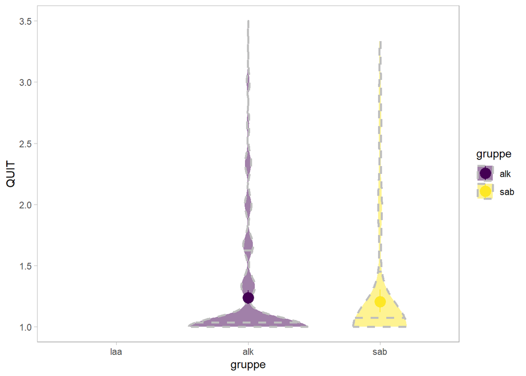

```r
violin_plot(nrw_p,
            eval(p_var),
            eval(p_vergleich))
```

**Deskriptive Ergebnisse**

In der Spalte “group1” wird angezeigt, um welche Gruppe (Nummer der Kohorte oder Gruppe) es sich in der jeweiligen Zeile handelt

```r
psych::describeBy(nrw_p[[p_var]],
                  group = droplevels(nrw_p[[p_vergleich]]),
                  mat=TRUE,
                  digits=3)
```

```
    item group1 vars   n  mean    sd median trimmed mad min   max range  skew
X11    1    laa    1   0   NaN    NA     NA     NaN  NA Inf  -Inf  -Inf    NA
X12    2    alk    1 295 1.237 0.491      1   1.111   0   1 3.500 2.500 2.302
X13    3    sab    1 124 1.207 0.530      1   1.060   0   1 3.333 2.333 2.564
    kurtosis    se
X11       NA    NA
X12    4.853 0.029
X13    5.611 0.048
```

**Kohorten und Gruppen mit Daten**

Anzahl der Teilnehmenden je Gruppe und Kohorte:

```r
nrw %>%
  dplyr::filter(!is.na(get(p_var))) %>%
  {table(.$gruppe, .$kohorte)}
```

```
        1   2   3   4
  laa   0   0   0   0
  alk   0   0   0 295
  sab   0   0   0 124
```

### 2.3.7 Partizipation der Lehramtsanwärter_innen

**Abbildung**

```r
rm(p_var)
rm(p_vergleich)
rm(p_kohorten)
rm(p_gruppe)

############################################### #
### Welche VARIABLE soll ausgegeben werden?   ###
############################################### #
p_var <- "SExMPART" # Variable in Anführungszeichen angeben

############################################### #
### Welcher VERGLEICH soll angestellt werden? ###
############################################### #
p_vergleich <- "gruppe" # Möglich ist: "kohorte" oder "gruppe"

############################################### #
### Welche KOHORTEN sollen ausgegeben werden? ###
############################################### #
# p_kohorten <- c("3", "4") # Verfügbar: "1", "2", "3", "4"
                          # Einfach auskommentieren, wenn
                          # alle ausgegeben werden sollen

############################################### #
### Welche GRUPPEN sollen ausgegeben werden?  ###
############################################### #
# p_gruppe <- c("laa") # Verfügbar: "laa" (Lehramtsanwärter*innen),
                     #            "sab" (Seminarausbilder*innen)
                     #            "alk" (Ausbildungslehrkräfte)
                     # Einfach auskommentieren, wenn
                     # alle ausgegeben werden sollen

nrw_p <- nrw
if (exists("p_kohorten")) {
  nrw_p <- nrw_p |>
    dplyr::filter(kohorte %in% p_kohorten)
}
if (exists("p_gruppe")) {
  nrw_p <- nrw_p |>
    dplyr::filter(gruppe %in% p_gruppe)
}
```

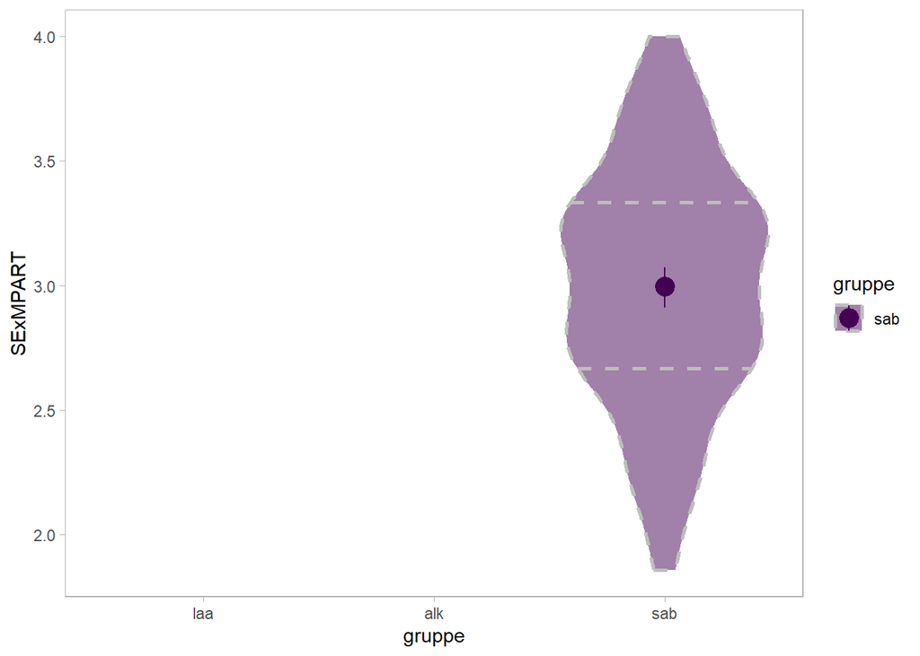

```r
violin_plot(nrw_p,
            eval(p_var),
            eval(p_vergleich))
```

**Deskriptive Ergebnisse**

In der Spalte “group1” wird angezeigt, um welche Gruppe (Nummer der Kohorte oder Gruppe) es sich in der jeweiligen Zeile handelt

```r
psych::describeBy(nrw_p[[p_var]],
                  group = droplevels(nrw_p[[p_vergleich]]),
                  mat=TRUE,
                  digits=3)
```

```
    item group1 vars   n  mean    sd median trimmed   mad   min  max range
X11    1    laa    1   0   NaN    NA     NA     NaN    NA   Inf -Inf  -Inf
X12    2    alk    1   0   NaN    NA     NA     NaN    NA   Inf -Inf  -Inf
X13    3    sab    1 133 2.997 0.479      3   3.004 0.424 1.857    4 2.143
      skew kurtosis    se
X11     NA       NA    NA
X12     NA       NA    NA
X13 -0.151   -0.493 0.041
```

**Kohorten und Gruppen mit Daten**

Anzahl der Teilnehmenden je Gruppe und Kohorte:

```r
nrw %>%
  dplyr::filter(!is.na(get(p_var))) %>%
  {table(.$gruppe, .$kohorte)}
```

```
        1   2   3   4
  laa   0   0   0   0
  alk   0   0   0   0
  sab   0   0   0 133
```

### 2.3.8 Eignungseinschätzung: Anteil

**Abbildung**

```r
rm(p_var)
rm(p_vergleich)
rm(p_kohorten)
rm(p_gruppe)

############################################### #
### Welche VARIABLE soll ausgegeben werden?   ###
############################################### #
p_var <- "eignp" # Variable in Anführungszeichen angeben

############################################### #
### Welcher VERGLEICH soll angestellt werden? ###
############################################### #
p_vergleich <- "gruppe" # Möglich ist: "kohorte" oder "gruppe"

############################################### #
### Welche KOHORTEN sollen ausgegeben werden? ###
############################################### #
# p_kohorten <- c("3", "4") # Verfügbar: "1", "2", "3", "4"
                          # Einfach auskommentieren, wenn
                          # alle ausgegeben werden sollen

############################################### #
### Welche GRUPPEN sollen ausgegeben werden?  ###
############################################### #
# p_gruppe <- c("laa") # Verfügbar: "laa" (Lehramtsanwärter*innen),
                     #            "sab" (Seminarausbilder*innen)
                     #            "alk" (Ausbildungslehrkräfte)
                     # Einfach auskommentieren, wenn
                     # alle ausgegeben werden sollen

nrw_p <- nrw
if (exists("p_kohorten")) {
  nrw_p <- nrw_p |>
    dplyr::filter(kohorte %in% p_kohorten)
}
if (exists("p_gruppe")) {
  nrw_p <- nrw_p |>
    dplyr::filter(gruppe %in% p_gruppe)
}
```

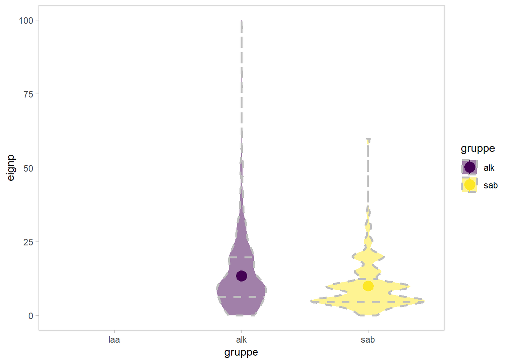

```r
violin_plot(nrw_p,
            eval(p_var),
            eval(p_vergleich))
```

**Deskriptive Ergebnisse**

In der Spalte “group1” wird angezeigt, um welche Gruppe (Nummer der Kohorte oder Gruppe) es sich in der jeweiligen Zeile handelt

```r
psych::describeBy(nrw_p[[p_var]],
                  group = droplevels(nrw_p[[p_vergleich]]),
                  mat=TRUE,
                  digits=3)
```

```
    item group1 vars   n   mean     sd median trimmed   mad min  max range
X11    1    laa    1   0    NaN     NA     NA     NaN    NA Inf -Inf  -Inf
X12    2    alk    1 325 13.532 12.482     10  11.805 7.413   0  100   100
X13    3    sab    1 113 10.035  8.377     10   8.868 7.413   0   60    60
     skew kurtosis    se
X11    NA       NA    NA
X12 2.305    9.422 0.692
X13 2.486   10.115 0.788
```

**Kohorten und Gruppen mit Daten**

Anzahl der Teilnehmenden je Gruppe und Kohorte:

```r
nrw %>%
  dplyr::filter(!is.na(get(p_var))) %>%
  {table(.$gruppe, .$kohorte)}
```

```
        1   2   3   4
  laa   0   0   0   0
  alk   0   0   0 325
  sab   0   0   0 113
```

### 2.3.9 Eignungseinschätzung Lehramtsanwärter_innen (Item)

**Abbildung**

```r
rm(p_var)
rm(p_vergleich)
rm(p_kohorten)
rm(p_gruppe)

############################################### #
### Welche VARIABLE soll ausgegeben werden?   ###
############################################### #
p_var <- "eign_01" # Variable in Anführungszeichen angeben

############################################### #
### Welcher VERGLEICH soll angestellt werden? ###
############################################### #
p_vergleich <- "gruppe" # Möglich ist: "kohorte" oder "gruppe"

############################################### #
### Welche KOHORTEN sollen ausgegeben werden? ###
############################################### #
# p_kohorten <- c("3", "4") # Verfügbar: "1", "2", "3", "4"
                          # Einfach auskommentieren, wenn
                          # alle ausgegeben werden sollen

############################################### #
### Welche GRUPPEN sollen ausgegeben werden?  ###
############################################### #
# p_gruppe <- c("laa") # Verfügbar: "laa" (Lehramtsanwärter*innen),
                     #            "sab" (Seminarausbilder*innen)
                     #            "alk" (Ausbildungslehrkräfte)
                     # Einfach auskommentieren, wenn
                     # alle ausgegeben werden sollen

nrw_p <- nrw
if (exists("p_kohorten")) {
  nrw_p <- nrw_p |>
    dplyr::filter(kohorte %in% p_kohorten)
}
if (exists("p_gruppe")) {
  nrw_p <- nrw_p |>
    dplyr::filter(gruppe %in% p_gruppe)
}
```

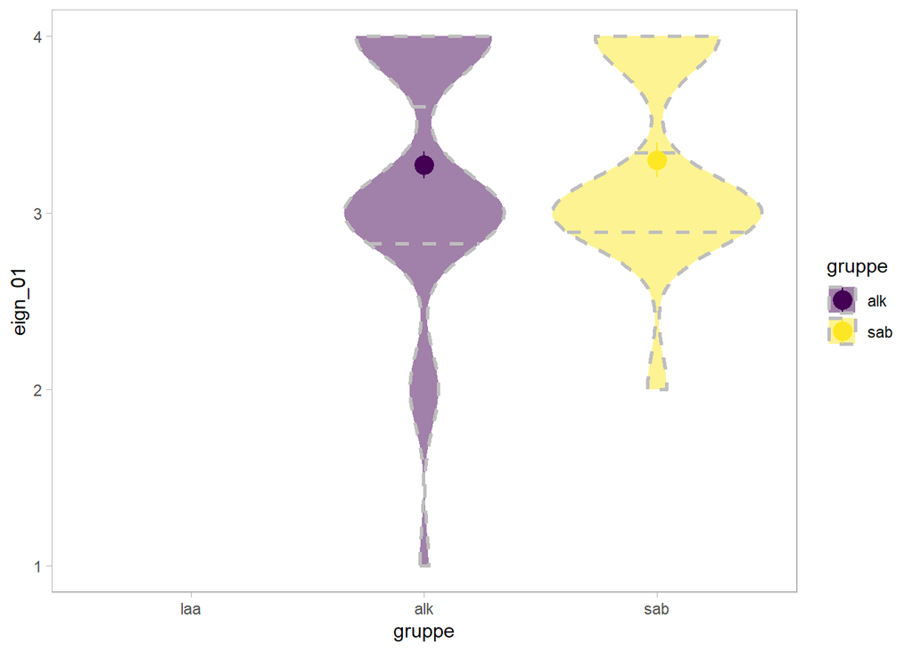

```r
violin_plot(nrw_p,
            eval(p_var),
            eval(p_vergleich))
```

**Deskriptive Ergebnisse**

In der Spalte “group1” wird angezeigt, um welche Gruppe (Nummer der Kohorte oder Gruppe) es sich in der jeweiligen Zeile handelt

```r
psych::describeBy(nrw_p[[p_var]],
                  group = droplevels(nrw_p[[p_vergleich]]),
                  mat=TRUE,
                  digits=3)
```

```
    item group1 vars   n  mean    sd median trimmed   mad min  max range   skew
X11    1    laa    1   0   NaN    NA     NA     NaN    NA Inf -Inf  -Inf     NA
X12    2    alk    1 338 3.269 0.728      3   3.368 1.483   1    4     3 -0.873
X13    3    sab    1 128 3.297 0.566      3   3.317 0.000   2    4     2 -0.069
    kurtosis   se
X11       NA   NA
X12    0.734 0.04
X13   -0.614 0.05
```

**Kohorten und Gruppen mit Daten**

Anzahl der Teilnehmenden je Gruppe und Kohorte:

```r
nrw %>%
  dplyr::filter(!is.na(get(p_var))) %>%
  {table(.$gruppe, .$kohorte)}
```

```
        1   2   3   4
  laa   0   0   0   0
  alk   0   0   0 338
  sab   0   0   0 128
```

### 2.3.10 Kooperation zwischen ZfsL und Ausbildungsschule

**Abbildung**

```r
rm(p_var)
rm(p_vergleich)
rm(p_kohorten)
rm(p_gruppe)

############################################### #
### Welche VARIABLE soll ausgegeben werden?   ###
############################################### #
p_var <- "KOZA" # Variable in Anführungszeichen angeben

############################################### #
### Welcher VERGLEICH soll angestellt werden? ###
############################################### #
p_vergleich <- "gruppe" # Möglich ist: "kohorte" oder "gruppe"

############################################### #
### Welche KOHORTEN sollen ausgegeben werden? ###
############################################### #
# p_kohorten <- c("3", "4") # Verfügbar: "1", "2", "3", "4"
                          # Einfach auskommentieren, wenn
                          # alle ausgegeben werden sollen

############################################### #
### Welche GRUPPEN sollen ausgegeben werden?  ###
############################################### #
# p_gruppe <- c("laa") # Verfügbar: "laa" (Lehramtsanwärter*innen),
                     #            "sab" (Seminarausbilder*innen)
                     #            "alk" (Ausbildungslehrkräfte)
                     # Einfach auskommentieren, wenn
                     # alle ausgegeben werden sollen

nrw_p <- nrw
if (exists("p_kohorten")) {
  nrw_p <- nrw_p |>
    dplyr::filter(kohorte %in% p_kohorten)
}
if (exists("p_gruppe")) {
  nrw_p <- nrw_p |>
    dplyr::filter(gruppe %in% p_gruppe)
}
```

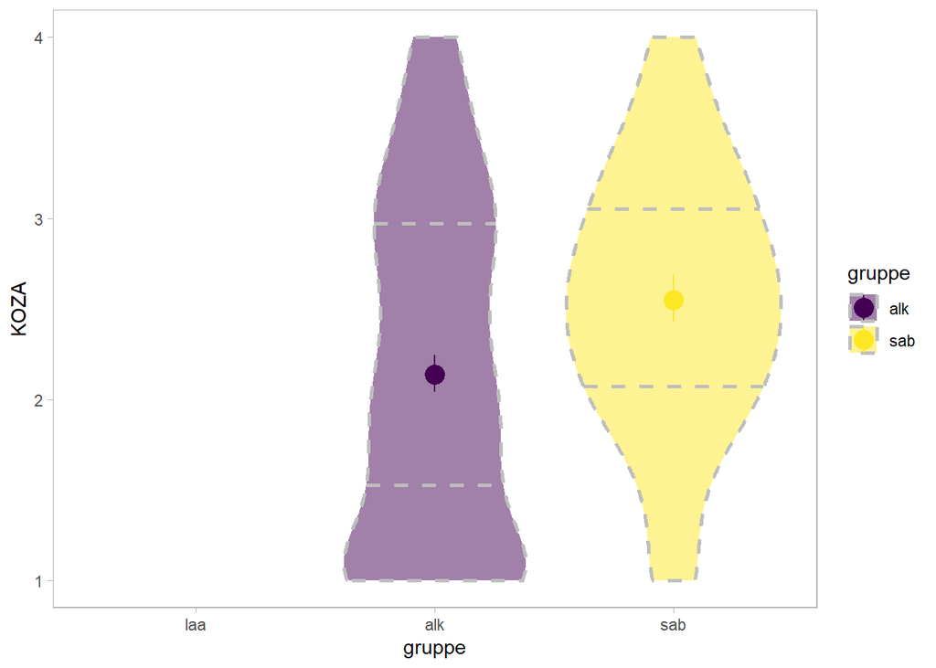

```r
violin_plot(nrw_p,
            eval(p_var),
            eval(p_vergleich))
```

**Deskriptive Ergebnisse**

In der Spalte “group1” wird angezeigt, um welche Gruppe (Nummer der Kohorte oder Gruppe) es sich in der jeweiligen Zeile handelt

```r
psych::describeBy(nrw_p[[p_var]],
                  group = droplevels(nrw_p[[p_vergleich]]),
                  mat=TRUE,
                  digits=3)
```

```
    item group1 vars   n  mean    sd median trimmed   mad min  max range   skew
X11    1    laa    1   0   NaN    NA     NA     NaN    NA Inf -Inf  -Inf     NA
X12    2    alk    1 302 2.139 0.942  2.000   2.076 1.483   1    4     3  0.318
X13    3    sab    1 122 2.551 0.728  2.667   2.560 0.741   1    4     3 -0.116
    kurtosis    se
X11       NA    NA
X12   -1.142 0.054
X13   -0.417 0.066
```

**Kohorten und Gruppen mit Daten**

Anzahl der Teilnehmenden je Gruppe und Kohorte:

```r
nrw %>%
  dplyr::filter(!is.na(get(p_var))) %>%
  {table(.$gruppe, .$kohorte)}
```

```
        1   2   3   4
  laa   0   0   0   0
  alk   0   0   0 302
  sab   0   0   0 122
```

### 2.3.11 Unterstützung durch höhere Ebenen

**Abbildung**

```r
rm(p_var)
rm(p_vergleich)
rm(p_kohorten)
rm(p_gruppe)

############################################### #
### Welche VARIABLE soll ausgegeben werden?   ###
############################################### #
p_var <- "SOZ" # Variable in Anführungszeichen angeben

############################################### #
### Welcher VERGLEICH soll angestellt werden? ###
############################################### #
p_vergleich <- "gruppe" # Möglich ist: "kohorte" oder "gruppe"

############################################### #
### Welche KOHORTEN sollen ausgegeben werden? ###
############################################### #
# p_kohorten <- c("3", "4") # Verfügbar: "1", "2", "3", "4"
                          # Einfach auskommentieren, wenn
                          # alle ausgegeben werden sollen

############################################### #
### Welche GRUPPEN sollen ausgegeben werden?  ###
############################################### #
# p_gruppe <- c("laa") # Verfügbar: "laa" (Lehramtsanwärter*innen),
                     #            "sab" (Seminarausbilder*innen)
                     #            "alk" (Ausbildungslehrkräfte)
                     # Einfach auskommentieren, wenn
                     # alle ausgegeben werden sollen

nrw_p <- nrw
if (exists("p_kohorten")) {
  nrw_p <- nrw_p |>
    dplyr::filter(kohorte %in% p_kohorten)
}
if (exists("p_gruppe")) {
  nrw_p <- nrw_p |>
    dplyr::filter(gruppe %in% p_gruppe)
}
```

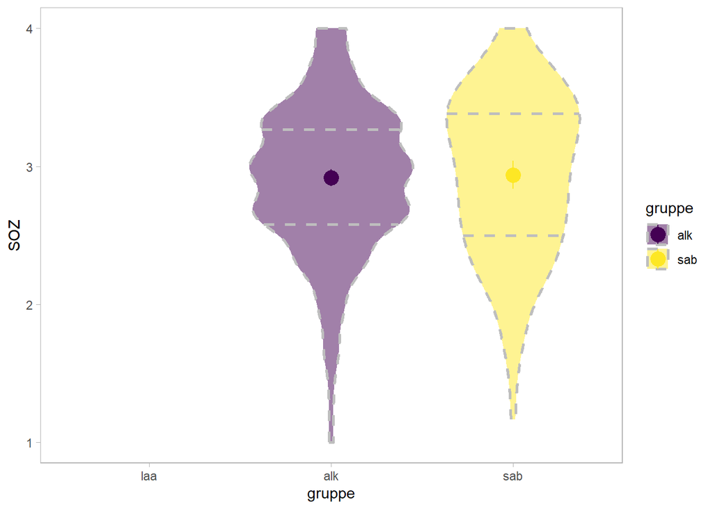

```r
violin_plot(nrw_p,
            eval(p_var),
            eval(p_vergleich))
```

**Deskriptive Ergebnisse**

In der Spalte “group1” wird angezeigt, um welche Gruppe (Nummer der Kohorte oder Gruppe) es sich in der jeweiligen Zeile handelt

```r
psych::describeBy(nrw_p[[p_var]],
                  group = droplevels(nrw_p[[p_vergleich]]),
                  mat=TRUE,
                  digits=3)
```

```
    item group1 vars   n  mean    sd median trimmed   mad   min  max range
X11    1    laa    1   0   NaN    NA     NA     NaN    NA   Inf -Inf  -Inf
X12    2    alk    1 304 2.917 0.542      3   2.932 0.494 1.000    4 3.000
X13    3    sab    1 123 2.938 0.583      3   2.966 0.741 1.167    4 2.833
      skew kurtosis    se
X11     NA       NA    NA
X12 -0.439    0.685 0.031
X13 -0.440   -0.334 0.053
```

**Kohorten und Gruppen mit Daten**

Anzahl der Teilnehmenden je Gruppe und Kohorte:

```r
nrw %>%
  dplyr::filter(!is.na(get(p_var))) %>%
  {table(.$gruppe, .$kohorte)}
```

```
        1   2   3   4
  laa   0   0   0   0
  alk   0   0   0 304
  sab   0   0   0 123
```

## 2.4 Lerngelegenheiten im VD

### 2.4.1 Unterrichtsbesuch: Authentizität

**Abbildung**

```r
rm(p_var)
rm(p_vergleich)
rm(p_kohorten)
rm(p_gruppe)

############################################### #
### Welche VARIABLE soll ausgegeben werden?   ###
############################################### #
p_var <- "ub_8" # Variable in Anführungszeichen angeben

############################################### #
### Welcher VERGLEICH soll angestellt werden? ###
############################################### #
p_vergleich <- "gruppe" # Möglich ist: "kohorte" oder "gruppe"

############################################### #
### Welche KOHORTEN sollen ausgegeben werden? ###
############################################### #
# p_kohorten <- c("3", "4") # Verfügbar: "1", "2", "3", "4"
                          # Einfach auskommentieren, wenn
                          # alle ausgegeben werden sollen

############################################### #
### Welche GRUPPEN sollen ausgegeben werden?  ###
############################################### #
# p_gruppe <- c("laa") # Verfügbar: "laa" (Lehramtsanwärter*innen),
                     #            "sab" (Seminarausbilder*innen)
                     #            "alk" (Ausbildungslehrkräfte)
                     # Einfach auskommentieren, wenn
                     # alle ausgegeben werden sollen

nrw_p <- nrw
if (exists("p_kohorten")) {
  nrw_p <- nrw_p |>
    dplyr::filter(kohorte %in% p_kohorten)
}
if (exists("p_gruppe")) {
  nrw_p <- nrw_p |>
    dplyr::filter(gruppe %in% p_gruppe)
}
```

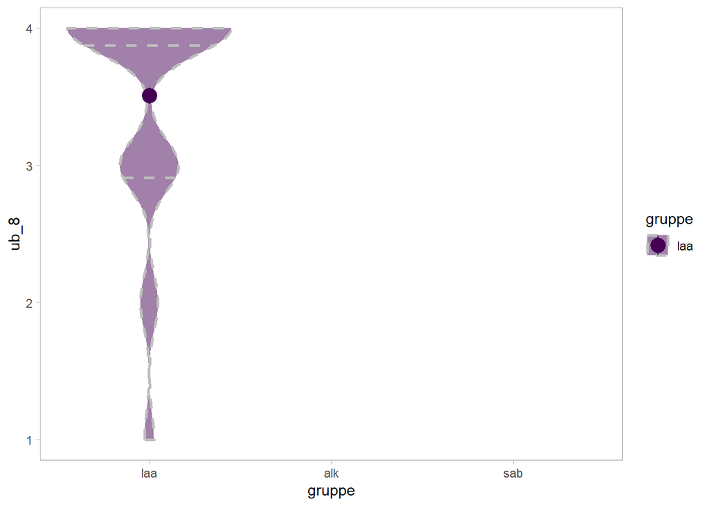

```r
violin_plot(nrw_p,
            eval(p_var),
            eval(p_vergleich))
```

**Deskriptive Ergebnisse**

In der Spalte “group1” wird angezeigt, um welche Gruppe (Nummer der Kohorte oder Gruppe) es sich in der jeweiligen Zeile handelt

```r
psych::describeBy(nrw_p[[p_var]],
                  group = droplevels(nrw_p[[p_vergleich]]),
                  mat=TRUE,
                  digits=3)
```

```
    item group1 vars   n  mean    sd median trimmed mad min  max range   skew
X11    1    laa    1 634 3.509 0.787      4   3.683   0   1    4     3 -1.631
X12    2    alk    1   0   NaN    NA     NA     NaN  NA Inf -Inf  -Inf     NA
X13    3    sab    1   0   NaN    NA     NA     NaN  NA Inf -Inf  -Inf     NA
    kurtosis    se
X11    2.004 0.031
X12       NA    NA
X13       NA    NA
```

**Kohorten und Gruppen mit Daten**

Anzahl der Teilnehmenden je Gruppe und Kohorte:

```r
nrw %>%
  dplyr::filter(!is.na(get(p_var))) %>%
  {table(.$gruppe, .$kohorte)}
```

```
        1   2   3   4
  laa   0   0   0 634
  alk   0   0   0   0
  sab   0   0   0   0
```

### 2.4.2 Unterrichtsbesuch: Sorgen

**Abbildung**

```r
rm(p_var)
rm(p_vergleich)
rm(p_kohorten)
rm(p_gruppe)

############################################### #
### Welche VARIABLE soll ausgegeben werden?   ###
############################################### #
p_var <- "ub_3" # Variable in Anführungszeichen angeben

############################################### #
### Welcher VERGLEICH soll angestellt werden? ###
############################################### #
p_vergleich <- "gruppe" # Möglich ist: "kohorte" oder "gruppe"

############################################### #
### Welche KOHORTEN sollen ausgegeben werden? ###
############################################### #
# p_kohorten <- c("3", "4") # Verfügbar: "1", "2", "3", "4"
                          # Einfach auskommentieren, wenn
                          # alle ausgegeben werden sollen

############################################### #
### Welche GRUPPEN sollen ausgegeben werden?  ###
############################################### #
# p_gruppe <- c("laa") # Verfügbar: "laa" (Lehramtsanwärter*innen),
                     #            "sab" (Seminarausbilder*innen)
                     #            "alk" (Ausbildungslehrkräfte)
                     # Einfach auskommentieren, wenn
                     # alle ausgegeben werden sollen

nrw_p <- nrw
if (exists("p_kohorten")) {
  nrw_p <- nrw_p |>
    dplyr::filter(kohorte %in% p_kohorten)
}
if (exists("p_gruppe")) {
  nrw_p <- nrw_p |>
    dplyr::filter(gruppe %in% p_gruppe)
}
```

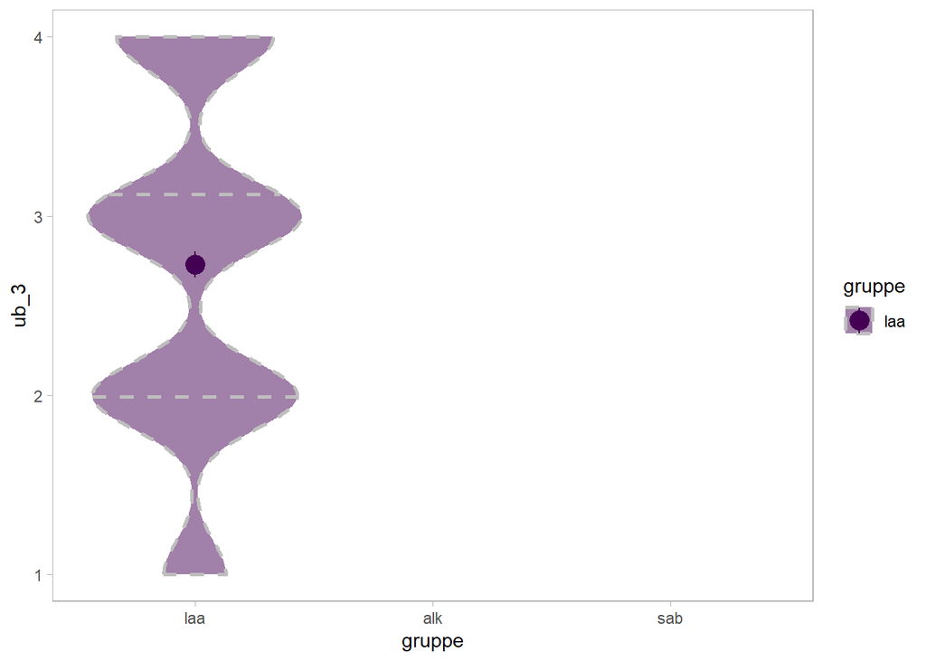

```r
violin_plot(nrw_p,
            eval(p_var),
            eval(p_vergleich))
```

**Deskriptive Ergebnisse**

In der Spalte “group1” wird angezeigt, um welche Gruppe (Nummer der Kohorte oder Gruppe) es sich in der jeweiligen Zeile handelt

```r
psych::describeBy(nrw_p[[p_var]],
                  group = droplevels(nrw_p[[p_vergleich]]),
                  mat=TRUE,
                  digits=3)
```

```
    item group1 vars   n  mean    sd median trimmed   mad min  max range   skew
X11    1    laa    1 635 2.729 0.941      3   2.784 1.483   1    4     3 -0.142
X12    2    alk    1   0   NaN    NA     NA     NaN    NA Inf -Inf  -Inf     NA
X13    3    sab    1   0   NaN    NA     NA     NaN    NA Inf -Inf  -Inf     NA
    kurtosis    se
X11   -0.951 0.037
X12       NA    NA
X13       NA    NA
```

**Kohorten und Gruppen mit Daten**

Anzahl der Teilnehmenden je Gruppe und Kohorte:

```r
nrw %>%
  dplyr::filter(!is.na(get(p_var))) %>%
  {table(.$gruppe, .$kohorte)}
```

```
        1   2   3   4
  laa   0   0   0 635
  alk   0   0   0   0
  sab   0   0   0   0
```

### 2.4.3 Unterrichtsbesuch: Erwarteter Zeitaufwand

**Abbildung**

```r
rm(p_var)
rm(p_vergleich)
rm(p_kohorten)
rm(p_gruppe)

############################################### #
### Welche VARIABLE soll ausgegeben werden?   ###
############################################### #
p_var <- "ub_7" # Variable in Anführungszeichen angeben

############################################### #
### Welcher VERGLEICH soll angestellt werden? ###
############################################### #
p_vergleich <- "gruppe" # Möglich ist: "kohorte" oder "gruppe"

############################################### #
### Welche KOHORTEN sollen ausgegeben werden? ###
############################################### #
# p_kohorten <- c("3", "4") # Verfügbar: "1", "2", "3", "4"
                          # Einfach auskommentieren, wenn
                          # alle ausgegeben werden sollen

############################################### #
### Welche GRUPPEN sollen ausgegeben werden?  ###
############################################### #
# p_gruppe <- c("laa") # Verfügbar: "laa" (Lehramtsanwärter*innen),
                     #            "sab" (Seminarausbilder*innen)
                     #            "alk" (Ausbildungslehrkräfte)
                     # Einfach auskommentieren, wenn
                     # alle ausgegeben werden sollen

nrw_p <- nrw
if (exists("p_kohorten")) {
  nrw_p <- nrw_p |>
    dplyr::filter(kohorte %in% p_kohorten)
}
if (exists("p_gruppe")) {
  nrw_p <- nrw_p |>
    dplyr::filter(gruppe %in% p_gruppe)
}
```

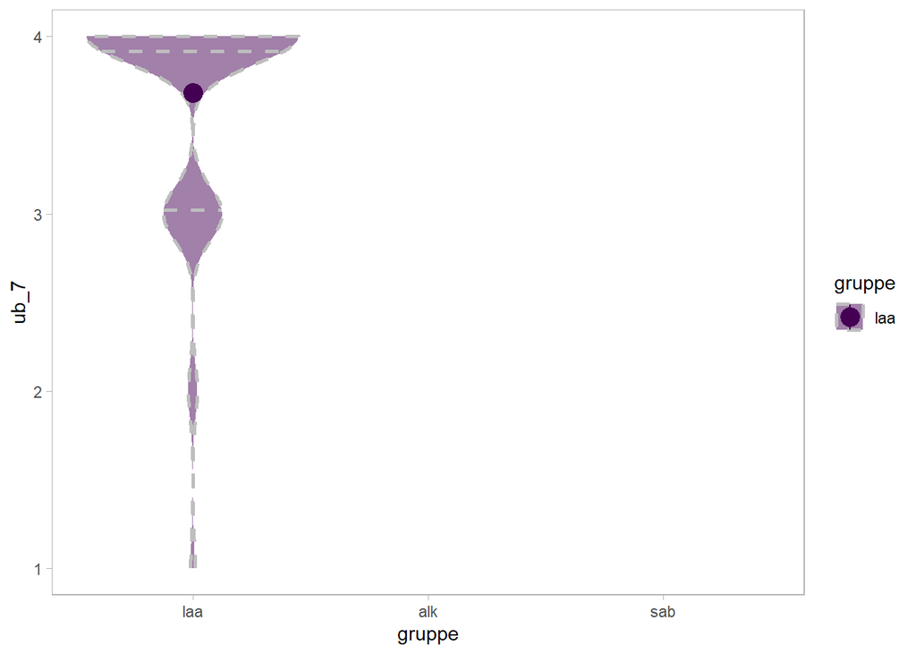

```r
violin_plot(nrw_p,
            eval(p_var),
            eval(p_vergleich))
```

**Deskriptive Ergebnisse**

In der Spalte “group1” wird angezeigt, um welche Gruppe (Nummer der Kohorte oder Gruppe) es sich in der jeweiligen Zeile handelt

```r
psych::describeBy(nrw_p[[p_var]],
                  group = droplevels(nrw_p[[p_vergleich]]),
                  mat=TRUE,
                  digits=3)
```

```
    item group1 vars   n  mean    sd median trimmed mad min  max range   skew
X11    1    laa    1 634 3.683 0.612      4   3.807   0   1    4     3 -2.166
X12    2    alk    1   0   NaN    NA     NA     NaN  NA Inf -Inf  -Inf     NA
X13    3    sab    1   0   NaN    NA     NA     NaN  NA Inf -Inf  -Inf     NA
    kurtosis    se
X11    4.991 0.024
X12       NA    NA
X13       NA    NA
```

**Kohorten und Gruppen mit Daten**

Anzahl der Teilnehmenden je Gruppe und Kohorte:

```r
nrw %>%
  dplyr::filter(!is.na(get(p_var))) %>%
  {table(.$gruppe, .$kohorte)}
```

```
        1   2   3   4
  laa   0   0   0 634
  alk   0   0   0   0
  sab   0   0   0   0
```